# **Challenge Project 02 - Warm Up: Machine Learning with a Heart**

*29 de março, 2020*

## **1. Descrição geral do problema**

[figure not shown]

As doenças cardíacas são a [principal causa de morte no mundo](https://www.world-heart-federation.org/resources/cardiovascular-diseases-cvds-global-facts-figures/). Para aprender a prevenir doenças cardíacas, precisamos primeiro aprender a detectá-las com segurança.

Nosso conjunto de dados é de um estudo de doenças cardíacas que está aberto ao público há muitos anos. O estudo coleta várias medidas sobre a saúde do paciente e as estatísticas cardiovasculares e, é claro, torna as identidades dos pacientes anônimas.

Os dados são fornecidos como cortesia do Cleveland Heart Disease Database) através do repositório UCI Machine Learning.

Prevenir doenças cardíacas é importante. Bons sistemas orientados a dados para prever doenças cardíacas podem melhorar todo o processo de pesquisa e prevenção, garantindo que mais pessoas possam ter uma vida saudável.

Nos Estados Unidos, os Centros de Controle e Prevenção de Doenças são um bom recurso para obter informações sobre doenças cardíacas. De acordo com [o site](https://www.cdc.gov/heartdisease/facts.htm):

- Cerca de 610.000 pessoas morrem de doenças cardíacas nos Estados Unidos a cada ano - isso é 1 em cada 4 mortes.
- As doenças cardíacas são a principal causa de morte para homens e mulheres. Mais da metade das mortes por doenças cardíacas em 2009 ocorreram em homens.
- A doença cardíaca coronária (DCC) é o tipo mais comum de doença cardíaca, matando mais de 370.000 pessoas anualmente.
- Todos os anos, cerca de 735.000 americanos sofrem um ataque cardíaco. Destes, 525.000 são um primeiro ataque cardíaco e 210.000 ocorrem em pessoas que já tiveram um ataque cardíaco.
- As doenças cardíacas são a principal causa de morte para pessoas da maioria das etnias dos Estados Unidos, incluindo afro-americanos, hispânicos e brancos. Para índios americanos ou nativos do Alasca e asiáticos ou ilhéus do Pacífico, as doenças cardíacas perdem apenas para o câncer.

Para obter mais informações, consulte o site dos [centros de controle e prevenção de doenças](https://www.cdc.gov/heartdisease/prevention.htm).

**Objetivo:** utilizar a **linguagem R** para prever a classe *binária heart_disease_present*, que representa se um paciente tem ou não uma doença cardíaca utilizando para a avaliação de desempenho dos modelos preditivos a serem criados a métrica Logloss).

## **2. Carregando Dados**

### **2.1 Importando bibliotecas necessárias**

Vamos começar nosso projeto importanto todas as bilbiotecas necessárias para a realização das fases iniciais de exploração e transformação dos dados (*Data Munging*).

```r
# Definindo a oculatação de warnings.

options(warn = -1)

# Caso não possua uma das bibliotecas importadas abaixo, a instale com o comando a seguir:

install.packages(c(
    'dplyr',
    'corrplot',
    'ggplot2',
    'gmodels',
    'vcd',
    'pROC',
    'e1071'
))
```

```r
# Importando bibliotecas.

library(dplyr)
library(corrplot)
library(ggplot2)
library(gmodels)
library(vcd)
library(pROC)
library(e1071)
```

### **2.2 Carregando dados**

```r
# Importando os dados do dataset.

dataset <- read.table("/content/datasets/heart.dat")

# Visualizando dados Importados.

head(dataset)
```

A data.frame: 6 × 14

|  | V1 <dbl> | V2 <dbl> | V3 <dbl> | V4 <dbl> | V5 <dbl> | V6 <dbl> | V7 <dbl> | V8 <dbl> | V9 <dbl> | V10 <dbl> | V11 <dbl> | V12 <dbl> | V13 <dbl> | V14 <int> |
| --- | --- | --- | --- | --- | --- | --- | --- | --- | --- | --- | --- | --- | --- | --- |
| 1 | 70 | 1 | 4 | 130 | 322 | 0 | 2 | 109 | 0 | 2.4 | 2 | 3 | 3 | 2 |
| 2 | 67 | 0 | 3 | 115 | 564 | 0 | 2 | 160 | 0 | 1.6 | 2 | 0 | 7 | 1 |
| 3 | 57 | 1 | 2 | 124 | 261 | 0 | 0 | 141 | 0 | 0.3 | 1 | 0 | 7 | 2 |
| 4 | 64 | 1 | 4 | 128 | 263 | 0 | 0 | 105 | 1 | 0.2 | 2 | 1 | 7 | 1 |
| 5 | 74 | 0 | 2 | 120 | 269 | 0 | 2 | 121 | 1 | 0.2 | 1 | 1 | 3 | 1 |
| 6 | 65 | 1 | 4 | 120 | 177 | 0 | 0 | 140 | 0 | 0.4 | 1 | 0 | 7 | 1 |

```r
# Renomeando colunas do dataset.

names(dataset) <- c('age', 'sex',
                  'chest_pain_type',
                  'resting_blood_pressure',
                  'serum_cholestoral',
                  'fasting_blood_sugar',
                  'resting_electro_results',
                  'max_heart_rate_achieved',
                  'exercise_induced_angina',
                  'oldpeak',
                  'slope_of_the_peak',
                  'number_of_major_vessels',
                  'thal',
                  'heart_disease')
```

```r
# Criando uma cópia do dataset.

data <- dataset
```

## **3. Data Munging - Preparando dados para a análise exploratória**

### **3.1 Visão geral dos dados**

Segundo as documentações do [DrivenData](https://www.drivendata.org/competitions/54/machine-learning-with-a-heart/page/108/) e da UCI Machine Learning Repository) referente ao projeto, cada linha dos dados contém um registro, com as seguintes variáveis:

[output not shown]

Nesta etapa vamos buscar organizar os dados das variáveis para efetuar a análise exploratória e extrair insigths que possam auxiliar no processo de criação dos modelos preditivos.

```r
# Verificando os tipos das colunas carregadas no dataset.

glimpse(data)
```

```
Rows: 270
Columns: 14
$ age                     <dbl> 70, 67, 57, 64, 74, 65, 56, 59, 60, 63, 59, 5…
$ sex                     <dbl> 1, 0, 1, 1, 0, 1, 1, 1, 1, 0, 1, 1, 1, 1, 0, …
$ chest_pain_type         <dbl> 4, 3, 2, 4, 2, 4, 3, 4, 4, 4, 4, 4, 3, 1, 4, …
$ resting_blood_pressure  <dbl> 130, 115, 124, 128, 120, 120, 130, 110, 140, …
$ serum_cholestoral       <dbl> 322, 564, 261, 263, 269, 177, 256, 239, 293, …
$ fasting_blood_sugar     <dbl> 0, 0, 0, 0, 0, 0, 1, 0, 0, 0, 0, 0, 0, 0, 0, …
$ resting_electro_results <dbl> 2, 2, 0, 0, 2, 0, 2, 2, 2, 2, 0, 2, 2, 0, 2, …
$ max_heart_rate_achieved <dbl> 109, 160, 141, 105, 121, 140, 142, 142, 170, …
$ exercise_induced_angina <dbl> 0, 0, 0, 1, 1, 0, 1, 1, 0, 0, 0, 1, 0, 0, 0, …
$ oldpeak                 <dbl> 2.4, 1.6, 0.3, 0.2, 0.2, 0.4, 0.6, 1.2, 1.2, …
$ slope_of_the_peak       <dbl> 2, 2, 1, 2, 1, 1, 2, 2, 2, 2, 2, 1, 1, 2, 1, …
$ number_of_major_vessels <dbl> 3, 0, 0, 1, 1, 0, 1, 1, 2, 3, 0, 0, 0, 2, 1, …
$ thal                    <dbl> 3, 7, 7, 7, 3, 7, 6, 7, 7, 7, 7, 7, 3, 3, 3, …
$ heart_disease           <int> 2, 1, 2, 1, 1, 1, 2, 2, 2, 2, 1, 1, 1, 2, 1, …
```

Verificamos a existência de **14 variáveis** numéricas e **270 observações** dentro do dataset.

```r
# Verificando a existência de valores NA no dataset.

print(sapply(data, function(v) {
    anyNA(v)
}))
```

```
                    age                     sex         chest_pain_type
                  FALSE                   FALSE                   FALSE
 resting_blood_pressure       serum_cholestoral     fasting_blood_sugar
                  FALSE                   FALSE                   FALSE
resting_electro_results max_heart_rate_achieved exercise_induced_angina
                  FALSE                   FALSE                   FALSE
                oldpeak       slope_of_the_peak number_of_major_vessels
                  FALSE                   FALSE                   FALSE
                   thal           heart_disease
                  FALSE                   FALSE
```

Não foi detectado nenhum valor *NA* dentro do conjunto de dados.

```r
# Verificando o número de valores únicos presentes em cada uma das variáveis especificadas.

print(sapply(data, function(v) {
    length(unique(v))
}))
```

```
                    age                     sex         chest_pain_type
                     41                       2                       4
 resting_blood_pressure       serum_cholestoral     fasting_blood_sugar
                     47                     144                       2
resting_electro_results max_heart_rate_achieved exercise_induced_angina
                      3                      90                       2
                oldpeak       slope_of_the_peak number_of_major_vessels
                     39                       3                       4
                   thal           heart_disease
                      3                       2
```

### **3.2 Alterando tipos de dados das variáveis**

A partir da documentação fornecida sobre o conjunto de dados, iremos alterar o tipo de dado de cada variável.

```r
## Alterando o tipo da variável sex.

data$sex <- as.factor(data$sex)

# Alterando as etiquetas dos valores da variável.

levels(data$sex) <- c('F', 'M')

## Alterando o tipo da variável fasting_blood_sugar.

data$fasting_blood_sugar <- as.factor(data$fasting_blood_sugar)

# Alterando as etiquetas dos valores da variável.

levels(data$fasting_blood_sugar) <- c('No', 'Yes')

## Alterando o tipo da variável exercise_induced_angina.

data$exercise_induced_angina <- as.factor(data$exercise_induced_angina)

# Alterando as etiquetas dos valores da variável.

levels(data$exercise_induced_angina) <- c('No', 'Yes')

# Alterando o tipo da variável resting_electro_results.

data$resting_electro_results <- as.factor(data$resting_electro_results)

# Alterando o tipo da variável chest_pain_type.

data$chest_pain_type <- as.factor(data$chest_pain_type)

# Alterando o tipo da variável slope_of_the_peak.

data$slope_of_the_peak <- factor(data$slope_of_the_peak, ordered = T)

## Alterando o tipo da variável thal.

data$thal <- as.factor(data$thal)

# Alterando as etiquetas dos valores da variável.

levels(data$thal) <- c('Normal', 'Fixed defect', 'Reversable defect')

## Alterando o tipo da variável heart_disease.

data$heart_disease <- as.factor(data$heart_disease)

# Alterando as etiquetas dos valores da variável.

levels(data$heart_disease) <- c('No', 'Yes')

# Alterando o tipo da variável age.

data$age <- as.integer(data$age)

# Alterando o tipo da variável resting_blood_pressure.

data$resting_blood_pressure <- as.integer(data$resting_blood_pressure)

# Alterando o tipo da variável serum_cholestoral.

data$serum_cholestoral <- as.integer(data$serum_cholestoral)

# Alterando o tipo da variável max_heart_rate_achieved.

data$max_heart_rate_achieved <- as.integer(data$max_heart_rate_achieved)

# Alterando o tipo da variável number_of_major_vessels.

data$number_of_major_vessels <- as.factor(data$number_of_major_vessels)
```

```r
# Verificando os tipos das colunas carregadas no dataset.

glimpse(data)
```

```
Rows: 270
Columns: 14
$ age                     <int> 70, 67, 57, 64, 74, 65, 56, 59, 60, 63, 59, 5…
$ sex                     <fct> M, F, M, M, F, M, M, M, M, F, M, M, M, M, F, …
$ chest_pain_type         <fct> 4, 3, 2, 4, 2, 4, 3, 4, 4, 4, 4, 4, 3, 1, 4, …
$ resting_blood_pressure  <int> 130, 115, 124, 128, 120, 120, 130, 110, 140, …
$ serum_cholestoral       <int> 322, 564, 261, 263, 269, 177, 256, 239, 293, …
$ fasting_blood_sugar     <fct> No, No, No, No, No, No, Yes, No, No, No, No, …
$ resting_electro_results <fct> 2, 2, 0, 0, 2, 0, 2, 2, 2, 2, 0, 2, 2, 0, 2, …
$ max_heart_rate_achieved <int> 109, 160, 141, 105, 121, 140, 142, 142, 170, …
$ exercise_induced_angina <fct> No, No, No, Yes, Yes, No, Yes, Yes, No, No, N…
$ oldpeak                 <dbl> 2.4, 1.6, 0.3, 0.2, 0.2, 0.4, 0.6, 1.2, 1.2, …
$ slope_of_the_peak       <ord> 2, 2, 1, 2, 1, 1, 2, 2, 2, 2, 2, 1, 1, 2, 1, …
$ number_of_major_vessels <fct> 3, 0, 0, 1, 1, 0, 1, 1, 2, 3, 0, 0, 0, 2, 1, …
$ thal                    <fct> Normal, Reversable defect, Reversable defect,…
$ heart_disease           <fct> Yes, No, Yes, No, No, No, Yes, Yes, Yes, Yes,…
```

Perfeito, agora podemos ir para as próxima etapas de exploração dos dados.

### **3.3 Explorando a distribuição de cada variável individualmente**

Antes de começarmos, queremos deixar claro que quando utilizarmos expressões que descrevam uma pessoa como sendo **saudável** ou **sadia** estaremos especificamente declarando que ela não possui registros de doenças cardiovasculares.

Independente do indivíduo apresentar ou não outras doenças, adotaremos esta nomeclatura para aumentar a fluidez na escrita da nossa análise que tem como foco estudar problemas cardíacos.

#### **3.3.1 Criando funções auxiliares**

##### **3.3.1.1 Funções para a criação de gráficos**

Criaremos algumas funções para padronizar as plotagens de gráficos que efetuaremos.

```r
# Definindo um função para criar gráficos de barras.

barPlot <- function(col, data, target = 'heart_disease') {

    ggplot(data = data, aes(x = data[, col], fill = data[, target])) +
        geom_bar(alpha = 0.85, position = 'dodge') +
        ggtitle(paste("Bar chart for variable:", col)) +
        xlab(col) +
        labs(fill = "Heart Disease") +
        theme_bw()
}
```

```r
# Definindo um função para criar gráficos de densidade.

densityPlot <- function(col, data, target = 'heart_disease') {

    ggplot(data = data, aes(x = data[, col], fill = data[, target])) +
        geom_density(alpha = 0.85) +
        ggtitle(paste("Density chart for variable:", col)) +
        xlab(col) +
        labs(fill = "Heart Disease") +
        theme_bw()
}
```

```r
# Definindo um função para criar gráficos de boxplot.

boxPlot <- function(col, data, target = 'heart_disease') {

    ggplot(data = data, aes(x = data[, target],  y = data[, col], fill = data[, target])) +
        geom_boxplot(alpha = 0.85) +
        ggtitle(paste("Boxplot for variable:", col)) +
        ylab(col) +
        xlab("") +
        labs(fill = "Heart Disease") +
        theme_bw()
}
```

##### **3.3.1.2 Funções para calcular estatísticas**

Criaremos uma função para padronizar as estatísticas que calcularemos para cada uma das variáveis a serem estudadas.

```r
# Definindo um função para gerar um dataframe com as estatísticas de uma variável do dataset.

varStats <- function(col, data, target = 'heart_disease') {

    if(!is.factor(data[, col])) {

        # Calcula estatísticas de variáveis numéricas.

        data %>%
            group_by_at(target) %>%
            summarize(
                Min       = min(get(col)),
                Q1        = unname(quantile(get(col), probs = c(0.25))),
                Median    = median(get(col)),
                mean      = mean(get(col)),
                Q3        = unname(quantile(get(col), probs = c(0.75))),
                Max       = max(get(col)),
                Sd        = sd(get(col)),
                Sk        = skewness(get(col)),
                Ck        = kurtosis(get(col))
            )

    } else {

        # Calcula estatísticas de variáveis categóricas.

        l = list()

        # Contabiliza o número de registros dentro de cada classe da variável.

        l$variableClasses <- data %>%
            group_by_at(col) %>%
            summarise(
                count = n(),
                prop  = n() / nrow(data) * 100
            )

        # Contabiliza o número de registros dentro de cada classe da variável e segmenta cada subconjunto a partir
        #da variável alvo.

        l$variableClassesGroupedByTargetVariable <- data %>%
            group_by_at(c(col, target)) %>%
            summarise(
                count = n(),
                prop  = n() / nrow(data) * 100
            )

        # Retorna a lista com as estatísticas computadas.

        l
    }
}
```

O coeficente de **Assimetria (Skewness)** indica como os dados estão *distribuídos* e para interpretar seu resultado podemos olhar a tabela a seguir:

| Índice de Assimetria | Descrição |
| --- | --- |
| **SK ≈ 0** | Os dados são simétricos. Tanto a cauda do lado direito quanto a do lado esquerdo da função densidade de probabilidade são iguais; |
| **SK < 0** | A assimetria é negativa. A cauda do lado esquerdo da função densidade de probabilidade é maior que a do lado direito e; |
| **SK > 0** | A assimetria é positiva. A cauda do lado direito da função densidade de probabilidade é maior que a do lado esquerdo. |

O coeficiente de **Curtose (Kurtosis)** é uma medida que caracteriza o *achatamento da curva* da função de distribuição e para interpretar seu resultado podemos olhar a tabela a seguir:

| Índice de Curtose | Descrição |
| --- | --- |
| **CK ≈ 0** | A distribuição é normal e é chamada de Curtose *Mesocúrtica*; |
| **CK < 0** | A Cauda é mais leve que a normal. Para um coeficiente de Curtose negativo, tem-se uma Curtose *Platicúrtica* e; |
| **CK > 0** | A Cauda é mais pesada que a normal. Para um coeficiente de Curtose positivo, tem-se uma Curtose *Leptocúrtica*. |

**Atenção:** Há diferentes fórmulas para calcular estes coeficientes. Mas, para este estudo utilizamos as funções fornecidas pela biblioteca **e1071** com suas respectivas configurações padrão. Em caso de dúvida, consulte a [documentação](https://cran.r-project.org/web/packages/e1071/e1071.pdf).

#### **3.3.2 Variável age**

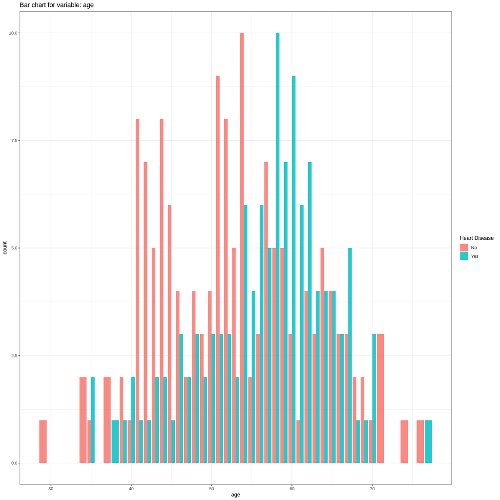

```r
# Definindo o nome da variável a ser analisada.

col <- 'age'

# Criando um gráfico de barras para a variável especificada.

barPlot(col, data)
```

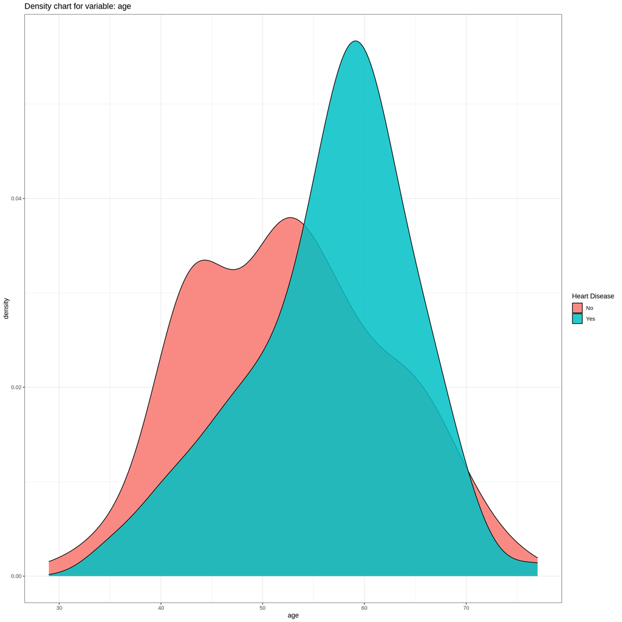

```r
# Criando um gráfico de densidade para a variável especificada.

densityPlot(col, data)
```

Os dados dos indivíduos que apresentam problemas cardíacos está mais deslocado para a direita quando comparado ao dos indivíduos que não apresentam estas dificuldades. Isto nos indica que as pessoas com problemas cardiovasculares tendem a ser mais velhas do que aquelas que apresentam um coração sadio.

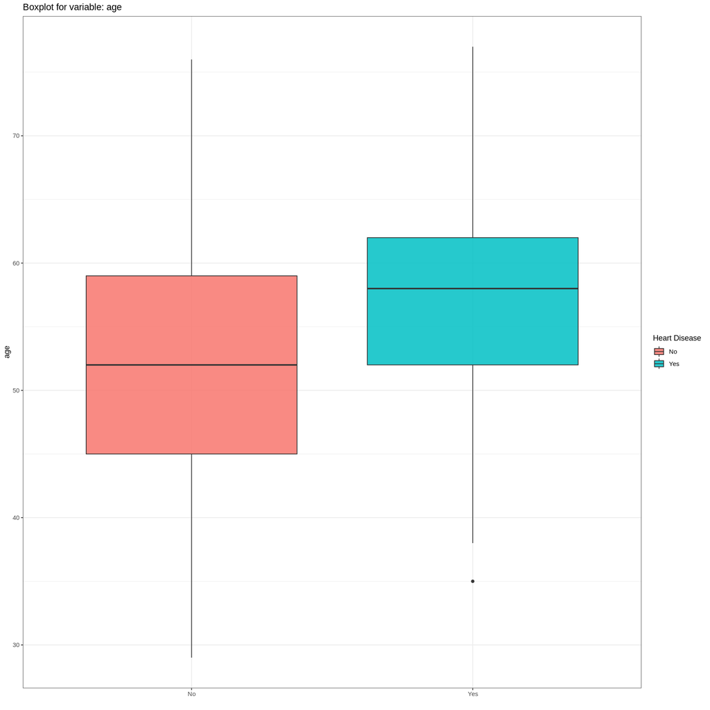

```r
# Criando um gráfico de boxplot para a variável especificada.

boxPlot(col, data)
```

O gráfico de boxplot nos permite detectar a presença de outliers dentro dos dados dos indivíduos que apresentam problemas cardíacos.

```r
# Calculando algumas estatísticas para a variável especificada.

varStats(col, data)
```

A tibble: 2 × 10

| heart_disease <fct> | Min <int> | Q1 <dbl> | Median <dbl> | mean <dbl> | Q3 <dbl> | Max <int> | Sd <dbl> | Sk <dbl> | Ck <dbl> |
| --- | --- | --- | --- | --- | --- | --- | --- | --- | --- |
| No | 29 | 45 | 52 | 52.70667 | 59 | 76 | 9.509830 | 0.1532323 | -0.63383151 |
| Yes | 35 | 52 | 58 | 56.59167 | 62 | 77 | 8.116273 | -0.5327168 | 0.01991217 |

Concluímos que há uma diferença mediana de **6 anos** entre os índividuos classificados com ou sem problemas cardíacos.

#### **3.3.3 Variável sex**

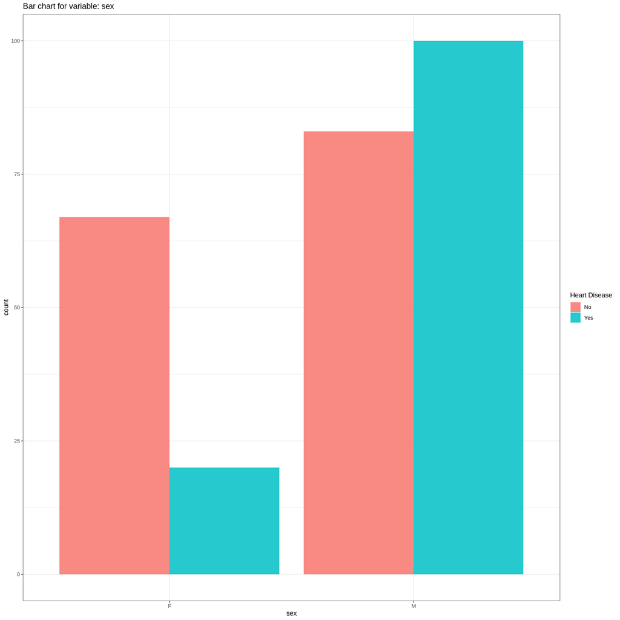

```r
# Definindo o nome da variável a ser analisada.

col <- 'sex'

# Criando um gráfico de barras para a variável especificada.

barPlot(col, data)
```

```r
# Calculando algumas estatísticas para a variável especificada.

stats <- varStats(col, data)

# Verificando a distribuição de registros entre as classes da variável.

stats$variableClasses
```

A tibble: 2 × 3

| sex <fct> | count <int> | prop <dbl> |
| --- | --- | --- |
| F | 87 | 32.22222 |
| M | 183 | 67.77778 |

Observamos que dentro do nosso conjunto de dados aproximadamente **32.2%** dos registros estão associados a mulheres e **67.8%** estão associados a homens.

```r
# Verificando a distribuição de registros entre as classes da variável especificada agrupadas pela variável alvo.

stats$variableClassesGroupedByTargetVariable
```

A grouped_df: 4 × 4

| sex <fct> | heart_disease <fct> | count <int> | prop <dbl> |
| --- | --- | --- | --- |
| F | No | 67 | 24.814815 |
| F | Yes | 20 | 7.407407 |
| M | No | 83 | 30.740741 |
| M | Yes | 100 | 37.037037 |

É interessante observar que a proporção de mulheres com problemas cardíacos dentro do conjunto de dados é aproximadamente **3.34 vezes menor** do que aquelas que estão saudáveis e **5 vezes menor** do que a proporção de homens doentes.

#### **3.3.4 Variável chest_pain_type**

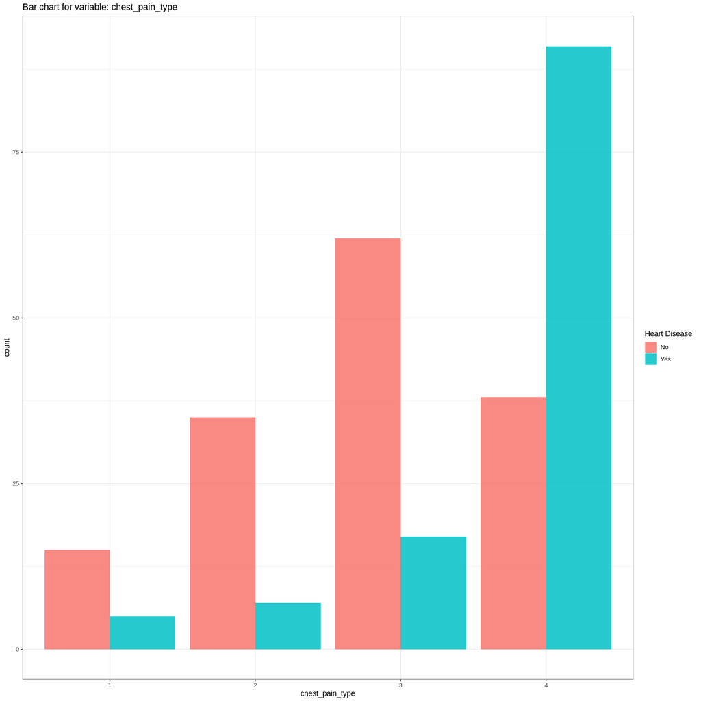

```r
# Definindo o nome da variável a ser analisada.

col <- 'chest_pain_type'

# Criando um gráfico de barras para a variável especificada.

barPlot(col, data)
```

Vemos que as pessoas que apresentam dores do tipo **1, 2 e 3** são predominantemente sadias, mas este padrão se inverte para a dor tipo **4** onde a maior parte dos indivíduos que a possuem apresentam problemas cardíacos.

```r
# Calculando algumas estatísticas para a variável especificada.

stats <- varStats(col, data)

# Verificando a distribuição de registros entre as classes da variável.

stats$variableClasses
```

A tibble: 4 × 3

| chest_pain_type <fct> | count <int> | prop <dbl> |
| --- | --- | --- |
| 1 | 20 | 7.407407 |
| 2 | 42 | 15.555556 |
| 3 | 79 | 29.259259 |
| 4 | 129 | 47.777778 |

Observamos que as proporções dos registros do tipo de dor crescem de maneira incremental, sendo a dor do *tipo 1* a **menos frequente (presente em aproximadamente 7.4% dos registros)** e a do *tipo 4* a **mais frequente (presente em aproximadamente 47.8% dos registros**).

```r
# Verificando a distribuição de registros entre as classes da variável especificada agrupadas pela variável alvo.

stats$variableClassesGroupedByTargetVariable
```

A grouped_df: 8 × 4

| chest_pain_type <fct> | heart_disease <fct> | count <int> | prop <dbl> |
| --- | --- | --- | --- |
| 1 | No | 15 | 5.555556 |
| 1 | Yes | 5 | 1.851852 |
| 2 | No | 35 | 12.962963 |
| 2 | Yes | 7 | 2.592593 |
| 3 | No | 62 | 22.962963 |
| 3 | Yes | 17 | 6.296296 |
| 4 | No | 38 | 14.074074 |
| 4 | Yes | 91 | 33.703704 |

Destacamos que **78.5%** dos indivíduos que apresentam a dor do *tipo 3* tem um coração saudável enquanto **70.5%** dos indivíduos que aprentam a dor do *tipo 4* possuem problemas cardíacos.

#### **3.3.5 Variável resting_blood_pressure**

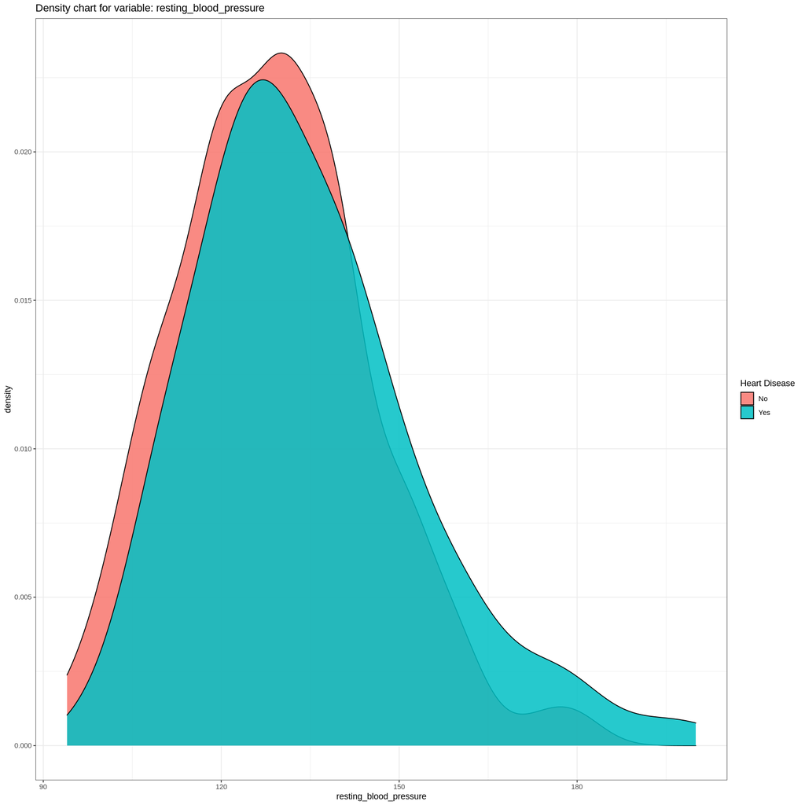

```r
# Definindo o nome da variável a ser analisada.

col <- 'resting_blood_pressure'

# Criando um gráfico de densidade para a variável especificada.

densityPlot(col, data)
```

Bom, parece que a pressão arterial de todos os indivíudos em repouso apresenta um valor mediano muito próximo independente da existência de problemas cardiovasculares.

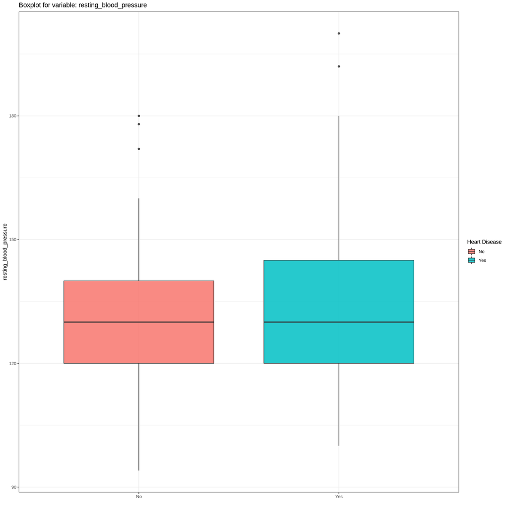

```r
# Criando um gráfico de boxplot para a variável especificada.

boxPlot(col, data)
```

O boxplot nos confirma que o valor mediano destes conjuntos de dados está muito próximo; nos permite detectar a exitência de outliers e ainda observar a significativa assimetria à direita dos dados dos indivíduos que apresentam doenças cardíacas.

```r
# Calculando algumas estatísticas para a variável especificada.

varStats(col, data)
```

A tibble: 2 × 10

| heart_disease <fct> | Min <int> | Q1 <dbl> | Median <dbl> | mean <dbl> | Q3 <dbl> | Max <int> | Sd <dbl> | Sk <dbl> | Ck <dbl> |
| --- | --- | --- | --- | --- | --- | --- | --- | --- | --- |
| No | 94 | 120 | 130 | 128.8667 | 140 | 180 | 16.45766 | 0.4052933 | 0.1702971 |
| Yes | 100 | 120 | 130 | 134.4417 | 145 | 200 | 19.09542 | 0.8665313 | 0.8092740 |

Veja só! O valor médiano para a pressão arterial dos indivíudos em repouso é o mesmo independente de estarem ou não doentes.

Note que o coeficiente de assimetria (**Sk**) também comprova nossa teoria de que a distribuição dos indivíduos com problemas cardíacos apresenta uma assimetria à direita.

#### **3.3.6 Variável serum_cholestoral**

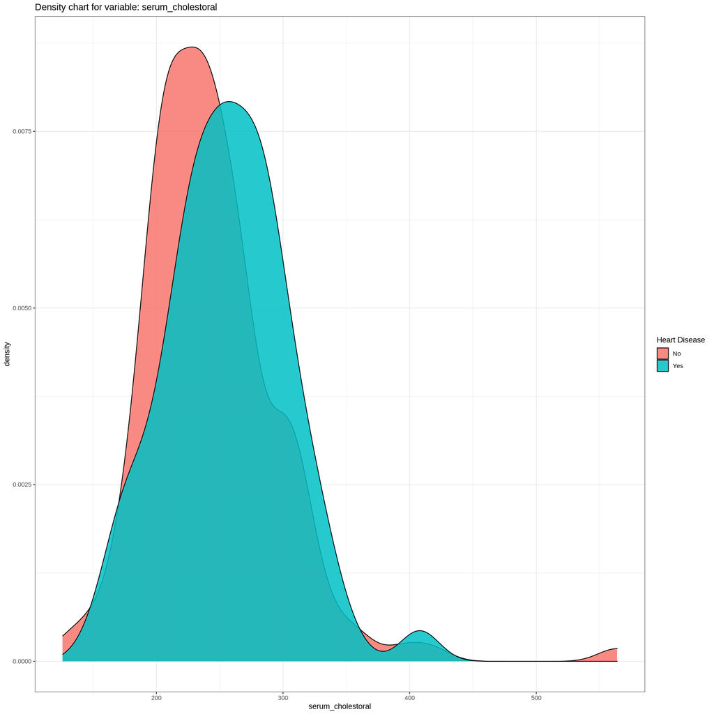

```r
# Definindo o nome da variável a ser analisada.

col <- 'serum_cholestoral'

# Criando um gráfico de densidade para a variável especificada.

densityPlot(col, data)
```

O gráfico de densidade está indicando que há uma diferença no valor mediano do colestorol sérico em *mg/dl* entre os individuos classificados com ou sem doenças cardíacas.

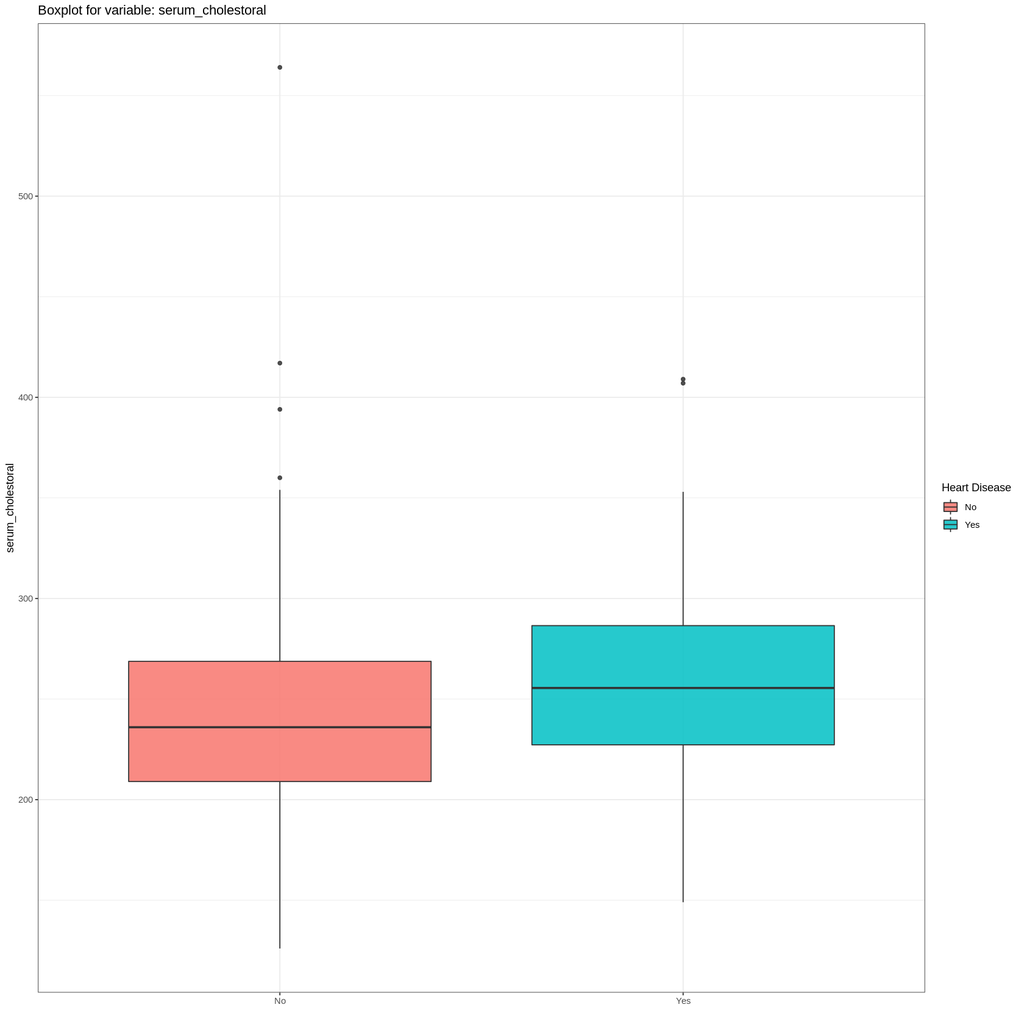

```r
# Criando um gráfico de boxplot para a variável especificada.

boxPlot(col, data)
```

```r
# Calculando algumas estatísticas para a variável especificada.

varStats(col, data)
```

A tibble: 2 × 10

| heart_disease <fct> | Min <int> | Q1 <dbl> | Median <dbl> | mean <dbl> | Q3 <dbl> | Max <int> | Sd <dbl> | Sk <dbl> | Ck <dbl> |
| --- | --- | --- | --- | --- | --- | --- | --- | --- | --- |
| No | 126 | 209.00 | 236.0 | 244.2133 | 268.75 | 564 | 54.01909 | 1.7472631 | 7.4636429 |
| Yes | 149 | 227.25 | 255.5 | 256.4667 | 286.50 | 409 | 47.96917 | 0.2888262 | 0.4057267 |

Concluímos que a diferença mediana entre as classes é de **19.5** *mg/dl*.

#### **3.3.7 Variável fasting_blood_sugar**

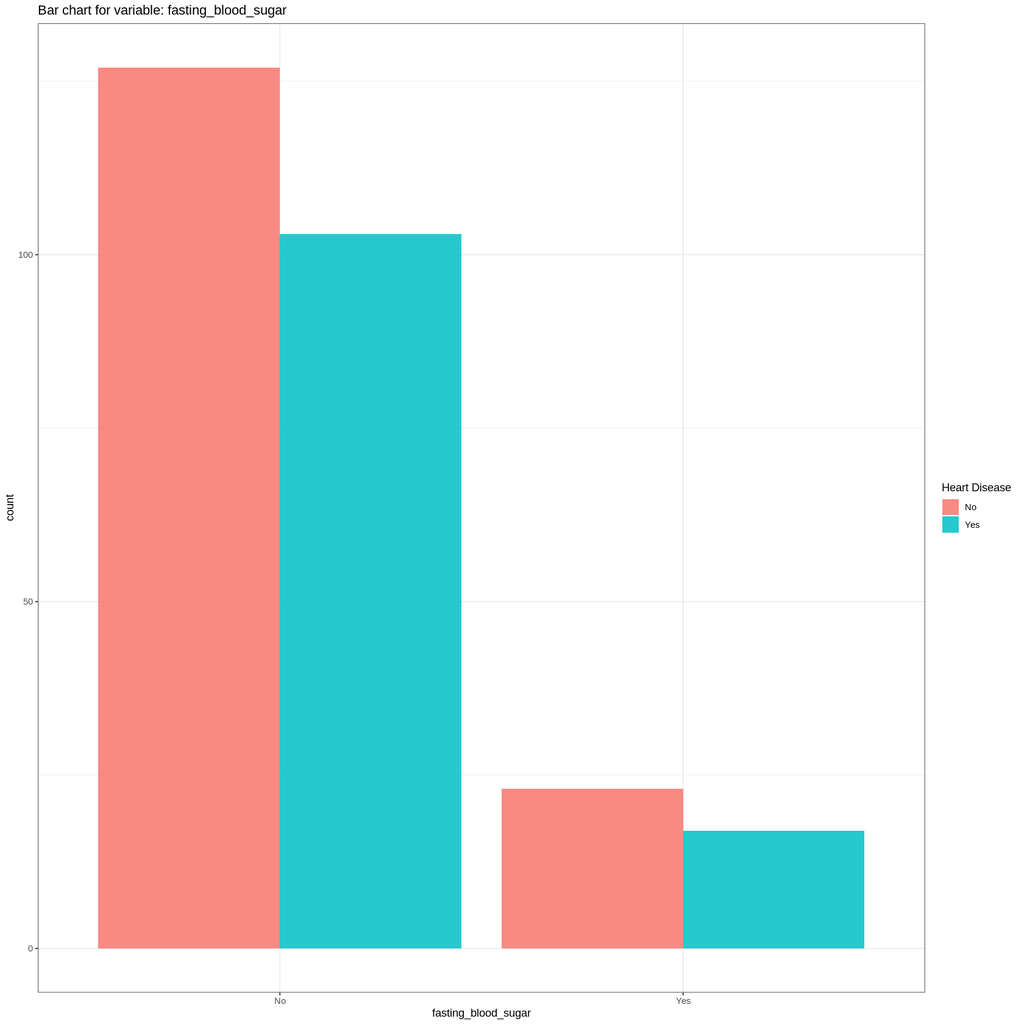

```r
# Definindo o nome da variável a ser analisada.

col <- 'fasting_blood_sugar'

# Criando um gráfico de barras para a variável especificada.

barPlot(col, data)
```

Interessante! A maior parte dos indivíduos registrados não possuem uma taxa de açúcar no sangue em jejum maior do que 120 *mg/dl*.

```r
# Calculando algumas estatísticas para a variável especificada.

stats <- varStats(col, data)

# Verificando a distribuição de registros entre as classes da variável.

stats$variableClasses
```

A tibble: 2 × 3

| fasting_blood_sugar <fct> | count <int> | prop <dbl> |
| --- | --- | --- |
| No | 230 | 85.18519 |
| Yes | 40 | 14.81481 |

Aproximadamente **14.8%** dos indivíduos registrados apresentam uma taxa de açúcar no sangue em jejum **maior** do que 120 *mg/dl*.

```r
# Verificando a distribuição de registros entre as classes da variável especificada agrupadas pela variável alvo.

stats$variableClassesGroupedByTargetVariable
```

A grouped_df: 4 × 4

| fasting_blood_sugar <fct> | heart_disease <fct> | count <int> | prop <dbl> |
| --- | --- | --- | --- |
| No | No | 127 | 47.037037 |
| No | Yes | 103 | 38.148148 |
| Yes | No | 23 | 8.518519 |
| Yes | Yes | 17 | 6.296296 |

Está tabela nos informa a proporção de registros em cada uma das classes da variável que avalia a taxa de açúcar no sangue agrupadas em subgrupos que indicam se o índividuo possui ou não problemas cardíacos. Mas, para este caso as informações fornecidas não nos ajudam a extrair muitas informações interessantes.

Por isso, vamos criar outra tabela em que dividimos a coluna **count** pelo número total de registros classificados em cada grupo da variável **fasting_blood_sugar** e recalcularemos as proporções. De maneira simples, o que estamos querendo é determinar se a proporção de indivíduos com problemas cardíacos varia muito entre a classe de indivíduos que apresentam ou não uma taxa de açúcar no sangue em jejum *maior* do que 120 *mg/dl*.

```r
# Calculando as proporções de indivíduos com ou sem problemas cardíacos dentro de cada classe da variável especificada.

stats$variableClassesGroupedByTargetVariable %>%
    group_by(fasting_blood_sugar) %>%
    mutate(prop = count / sum(count) * 100)
```

A grouped_df: 4 × 4

| fasting_blood_sugar <fct> | heart_disease <fct> | count <int> | prop <dbl> |
| --- | --- | --- | --- |
| No | No | 127 | 55.21739 |
| No | Yes | 103 | 44.78261 |
| Yes | No | 23 | 57.50000 |
| Yes | Yes | 17 | 42.50000 |

Vemos que as proporções são bem próximas.

Dentro da classe de indivíduos que **não** possuem uma taxa de açúcar no sangue em jejum maior do que 120 *mg/dl*, aproximadamente **55.2%** tem um coração sadio enquanto **44.8%** possuem doenças.

Dentro da classe de indivíduos que possuem uma taxa de açúcar no sangue em jejum maior do que 120 *mg/dl*, **57.5%** tem um coração sadio enquanto **42.5%** possuem doenças.

#### **3.3.8 Variável resting_electro_results**

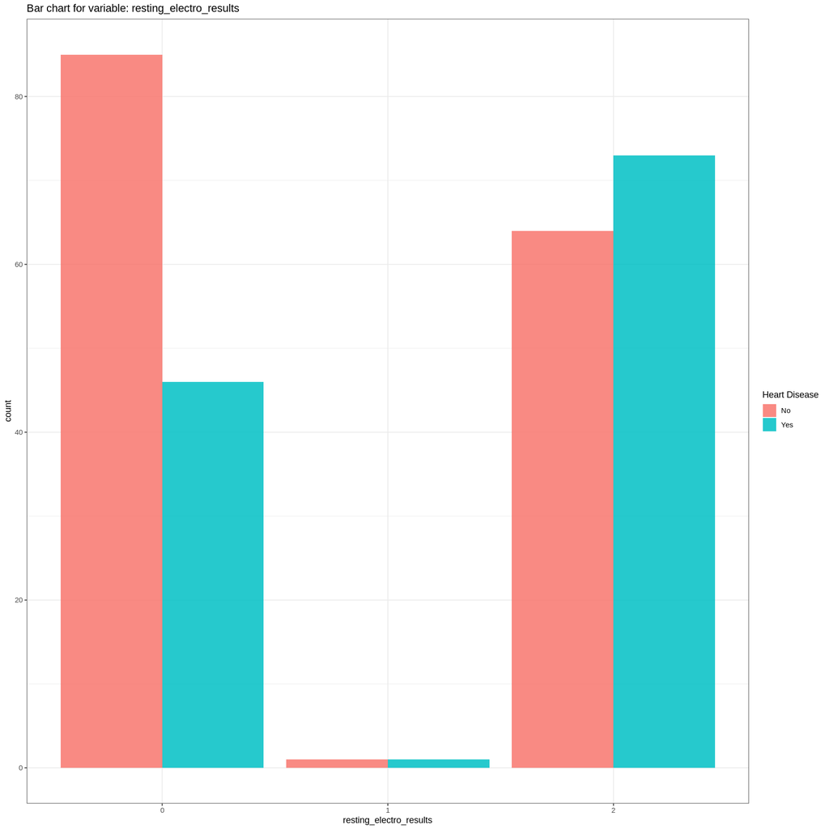

```r
# Definindo o nome da variável a ser analisada.

col <- 'resting_electro_results'

# Criando um gráfico de barras para a variável especificada.

barPlot(col, data)
```

Os resultados eletrocardiográficos em repouso que apresentam **valor 0** estão predominantemente associados a indivíduos que não possuem doenças enquanto aqueles classificados com o **valor 2** estão predominantemente associados a índivíduos doentes.

```r
# Calculando algumas estatísticas para a variável especificada.

stats <- varStats(col, data)

# Verificando a distribuição de registros entre as classes da variável.

stats$variableClasses
```

A tibble: 3 × 3

| resting_electro_results <fct> | count <int> | prop <dbl> |
| --- | --- | --- |
| 0 | 131 | 48.5185185 |
| 1 | 2 | 0.7407407 |
| 2 | 137 | 50.7407407 |

Os resultados eletrocardiográficos em repouso que obtiveram o **valor 1** são aqueles que apresentam a menor proporção dentro do conjunto de dados, aproximadamente **0.74%**.

```r
# Verificando a distribuição de registros entre as classes da variável especificada agrupadas pela variável alvo.

stats$variableClassesGroupedByTargetVariable
```

A grouped_df: 6 × 4

| resting_electro_results <fct> | heart_disease <fct> | count <int> | prop <dbl> |
| --- | --- | --- | --- |
| 0 | No | 85 | 31.4814815 |
| 0 | Yes | 46 | 17.0370370 |
| 1 | No | 1 | 0.3703704 |
| 1 | Yes | 1 | 0.3703704 |
| 2 | No | 64 | 23.7037037 |
| 2 | Yes | 73 | 27.0370370 |

Destacamos que dentro dos resultados eletrocardiográficos em repouso classificados com o **valor 0**, a quantidade de indivíduos que são sadios é cerca de **1.85** vezes **maior** do que aqueles que são doentes.

#### **3.3.9 Variável max_heart_rate_achieved**

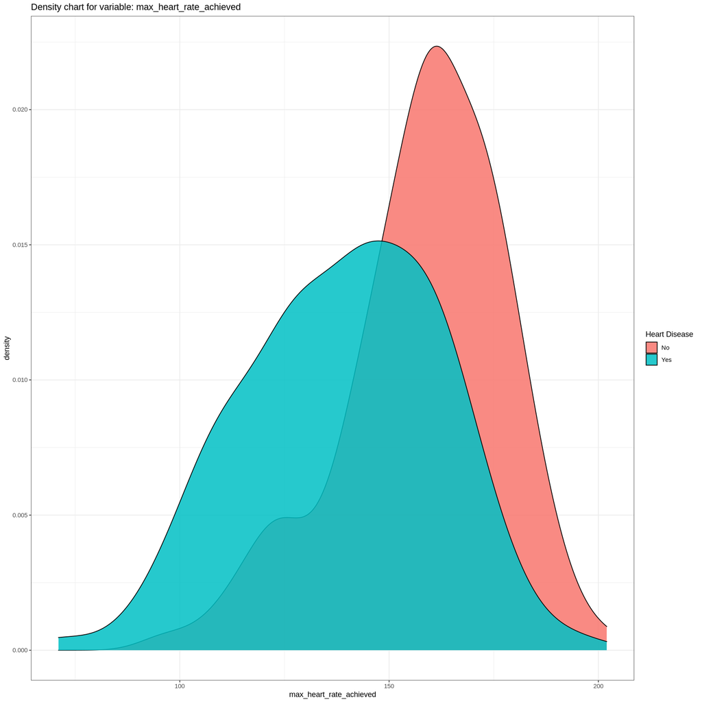

```r
# Definindo o nome da variável a ser analisada.

col <- 'max_heart_rate_achieved'

# Criando um gráfico de densidade para a variável especificada.

densityPlot(col, data)
```

Parece que o número mediano de batimentos cardíacos por minuto dos indivíduos sádios é maior do que o dos indivíduos com doenças.

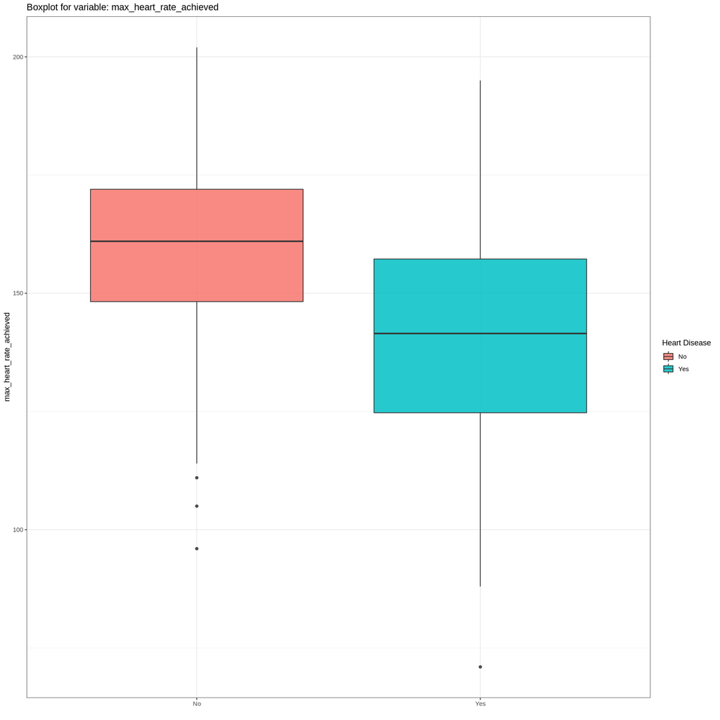

```r
# Criando um gráfico de boxplot para a variável especificada.

boxPlot(col, data)
```

Detectamos a existência de outliers dentro dos dois subconjuntos analisados.

```r
# Calculando algumas estatísticas para a variável especificada.

varStats(col, data)
```

A tibble: 2 × 10

| heart_disease <fct> | Min <int> | Q1 <dbl> | Median <dbl> | mean <dbl> | Q3 <dbl> | Max <int> | Sd <dbl> | Sk <dbl> | Ck <dbl> |
| --- | --- | --- | --- | --- | --- | --- | --- | --- | --- |
| No | 96 | 148.25 | 161.0 | 158.3333 | 172.00 | 202 | 19.28336 | -0.6639215 | 0.3710206 |
| Yes | 71 | 124.75 | 141.5 | 138.8583 | 157.25 | 195 | 23.13072 | -0.2390985 | -0.3985598 |

#### **3.3.10 Variável exercise_induced_angina**

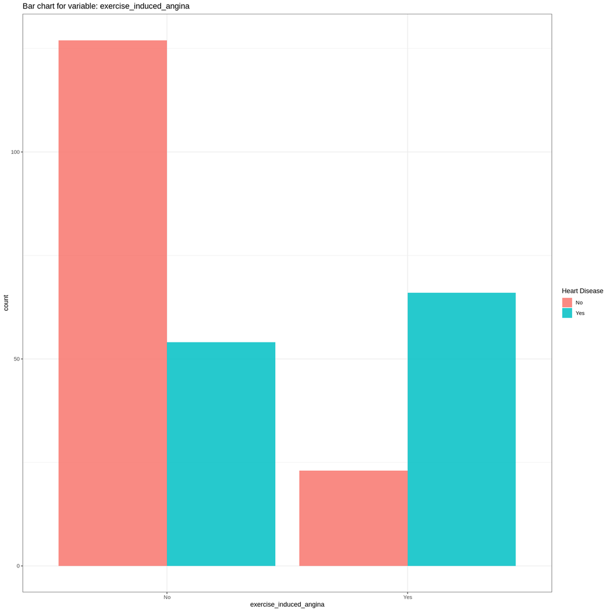

```r
# Definindo o nome da variável a ser analisada.

col <- 'exercise_induced_angina'

# Criando um gráfico de barras para a variável especificada.

barPlot(col, data)
```

Vemos que predominantemente não há dor no peito induzida por exercício para os indivíduos sadios, enquanto a maior parte dos doentes registraram sentir algo.

```r
# Calculando algumas estatísticas para a variável especificada.

stats <- varStats(col, data)

# Verificando a distribuição de registros entre as classes da variável.

stats$variableClasses
```

A tibble: 2 × 3

| exercise_induced_angina <fct> | count <int> | prop <dbl> |
| --- | --- | --- |
| No | 181 | 67.03704 |
| Yes | 89 | 32.96296 |

Observamos que em aproximadamente **67%** dos registros os indivíduos não sentiram dor no peito.

```r
# Verificando a distribuição de registros entre as classes da variável especificada agrupadas pela variável alvo.

stats$variableClassesGroupedByTargetVariable
```

A grouped_df: 4 × 4

| exercise_induced_angina <fct> | heart_disease <fct> | count <int> | prop <dbl> |
| --- | --- | --- | --- |
| No | No | 127 | 47.037037 |
| No | Yes | 54 | 20.000000 |
| Yes | No | 23 | 8.518519 |
| Yes | Yes | 66 | 24.444444 |

Por fim, verificamos que cerca de **24.4%** dos indivíduos apresenta dor no peito induzida por execícios e efetivamente possui doenças cardíacas.

#### **3.3.11 Variável oldpeak**

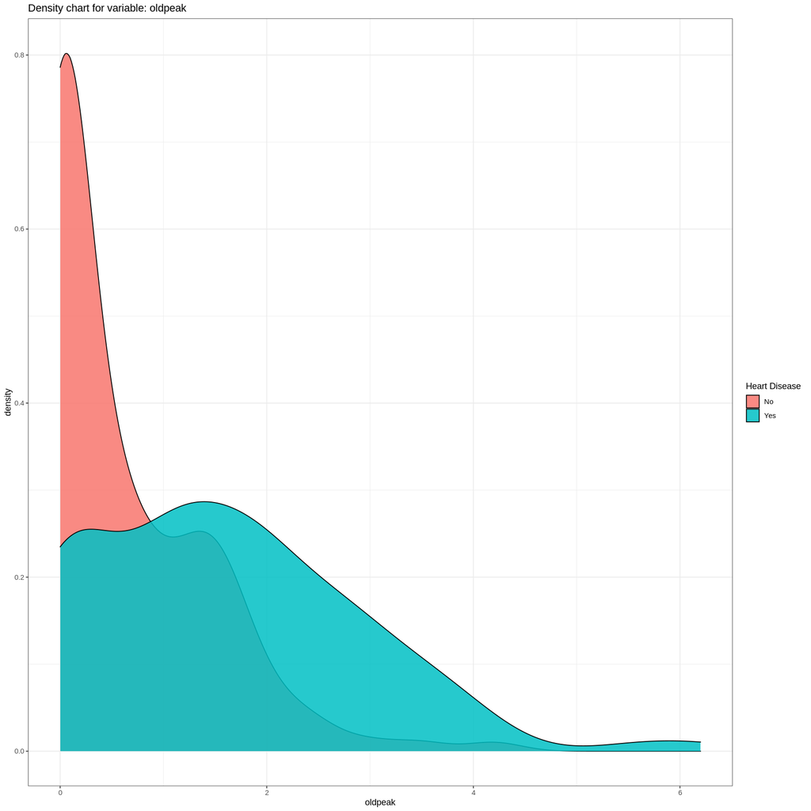

```r
# Definindo o nome da variável a ser analisada.

col <- 'oldpeak'

# Criando um gráfico de densidade para a variável especificada.

densityPlot(col, data)
```

Podemos ver uma clara diferença entre a distribuição desta medida de anormalidade nos eletrocardiogramas entre o conjunto de indivíduos sadios e os doentes.

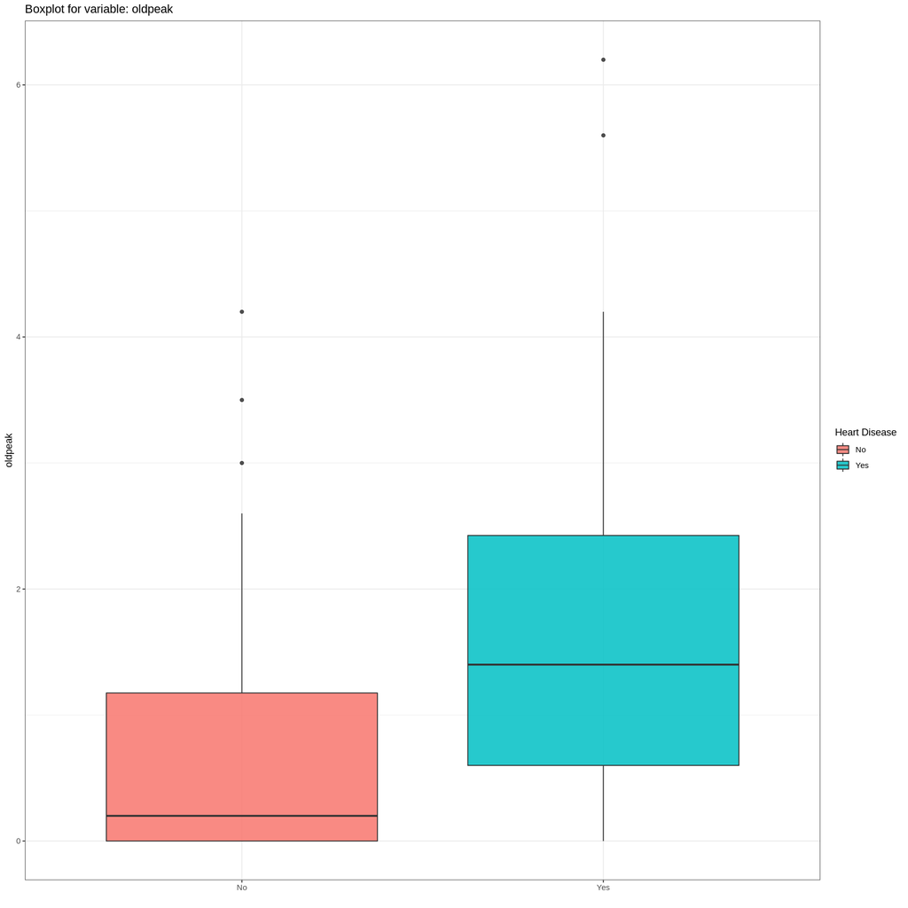

```r
# Criando um gráfico de boxplot para a variável especificada.

boxPlot(col, data)
```

Descobrimos a existência de outliers dentro dos conjuntos.

Note que esta medida de anormalidade tende a se concentrar próximo de um valor quando analisamos o conjunto de indivíduos saudáveis.

Quanto estudamos o conjunto de dados de pessoas doentes vemos que esta medida tende a variar muito mais.

```r
# Calculando algumas estatísticas para a variável especificada.

varStats(col, data)
```

A tibble: 2 × 10

| heart_disease <fct> | Min <dbl> | Q1 <dbl> | Median <dbl> | mean <dbl> | Q3 <dbl> | Max <dbl> | Sd <dbl> | Sk <dbl> | Ck <dbl> |
| --- | --- | --- | --- | --- | --- | --- | --- | --- | --- |
| No | 0 | 0.0 | 0.2 | 0.6226667 | 1.175 | 4.2 | 0.8008508 | 1.5252325 | 2.6036596 |
| Yes | 0 | 0.6 | 1.4 | 1.5841667 | 2.425 | 6.2 | 1.2820674 | 0.7569866 | 0.5796318 |

Concluímos destacando a diferença entre os valores medianos dos conjuntos e os altos índices de *Assimetria* e *Curtose* do grupo de indivíduos sem doenças.

#### **3.3.12 Variável slope_of_the_peak**

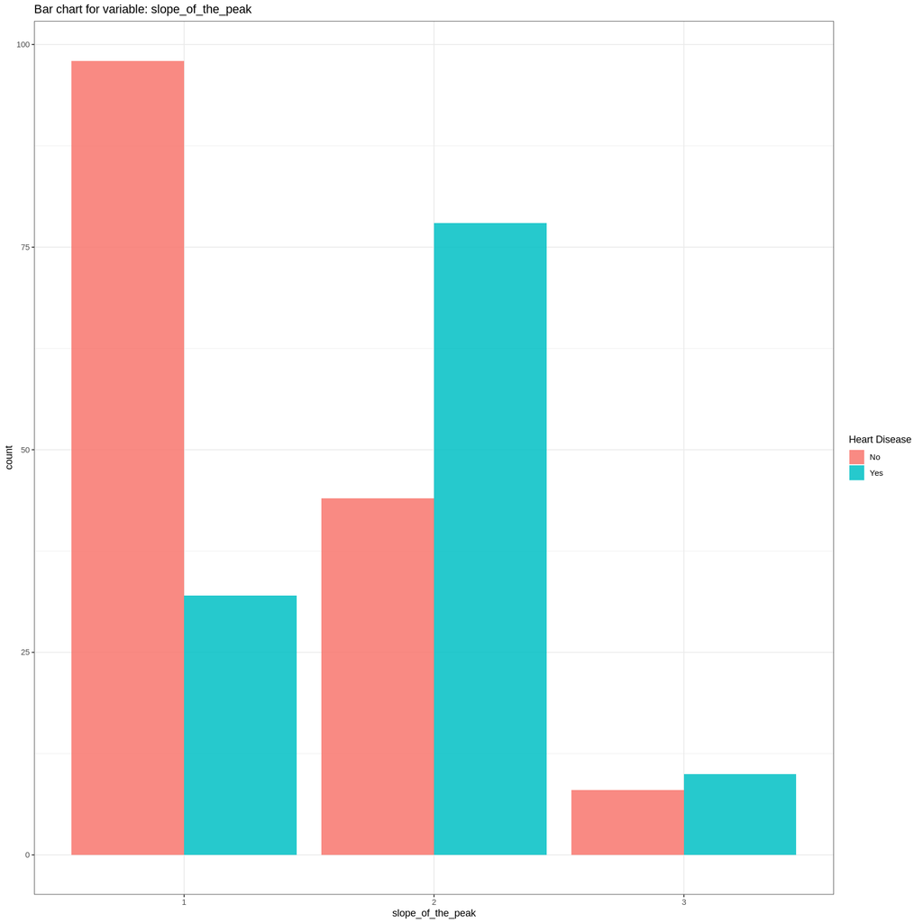

```r
# Definindo o nome da variável a ser analisada.

col <- 'slope_of_the_peak'

# Criando um gráfico de barras para a variável especificada.

barPlot(col, data)
```

Bom, o gráfico nos indica que a inclinação do *segmento ST* do pico do exercício e predominantemente **1** quando o indivíduo é sadio e **2 ou 3** quando apresenta alguma doença.

```r
# Calculando algumas estatísticas para a variável especificada.

stats <- varStats(col, data)

# Verificando a distribuição de registros entre as classes da variável.

stats$variableClasses
```

A tibble: 3 × 3

| slope_of_the_peak <ord> | count <int> | prop <dbl> |
| --- | --- | --- |
| 1 | 130 | 48.148148 |
| 2 | 122 | 45.185185 |
| 3 | 18 | 6.666667 |

A maior parte dos registros apresentam uma inclinação do *segmento ST* do pico do exercício com valor **1 ou 2**.

```r
# Verificando a distribuição de registros entre as classes da variável especificada agrupadas pela variável alvo.

stats$variableClassesGroupedByTargetVariable
```

A grouped_df: 6 × 4

| slope_of_the_peak <ord> | heart_disease <fct> | count <int> | prop <dbl> |
| --- | --- | --- | --- |
| 1 | No | 98 | 36.296296 |
| 1 | Yes | 32 | 11.851852 |
| 2 | No | 44 | 16.296296 |
| 2 | Yes | 78 | 28.888889 |
| 3 | No | 8 | 2.962963 |
| 3 | Yes | 10 | 3.703704 |

#### **3.3.13 Variável number_of_major_vessels**

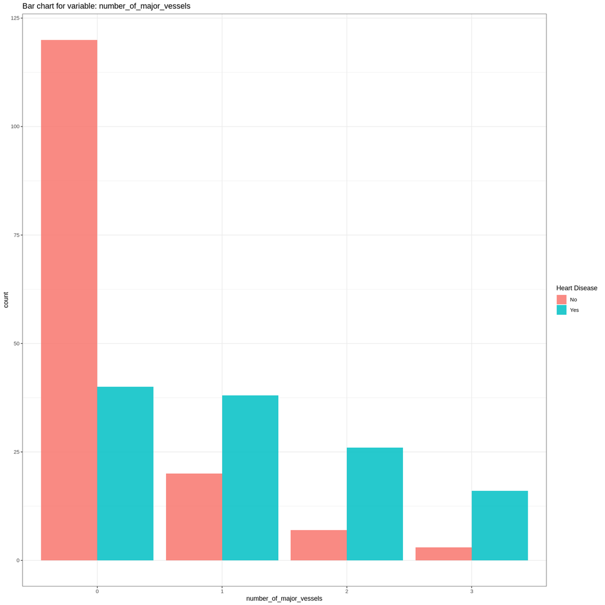

```r
# Definindo o nome da variável a ser analisada.

col <- 'number_of_major_vessels'

# Criando um gráfico de barras para a variável especificada.

barPlot(col, data)
```

O gráfico gerado por está variável é bem interessante! Veja que a medida que o número de vasos principais coloridos por *flourosopy* aumenta, a proporção de indivíduos saudáveis diminuiu drasticamente.

Vemos isso ao analisar a **coluna 0** e a **coluna 1**. Quando não há vasos principais coloridos por *flourosopy* o conjunto de dados é predominantemente de indivíduos sem doenças. Mas, basta que um vaso seja colorido para que essa predominância mude e os indivíduos com doenças passem a se destacar.

```r
# Calculando algumas estatísticas para a variável especificada.

stats <- varStats(col, data)

# Verificando a distribuição de registros entre as classes da variável.

stats$variableClasses
```

A tibble: 4 × 3

| number_of_major_vessels <fct> | count <int> | prop <dbl> |
| --- | --- | --- |
| 0 | 160 | 59.259259 |
| 1 | 58 | 21.481481 |
| 2 | 33 | 12.222222 |
| 3 | 19 | 7.037037 |

Temos em aproximadamente **59.26%** dos registros indivíduos que **não possuem vasos coloridos por flourosopy**.

```r
# Verificando a distribuição de registros entre as classes da variável especificada agrupadas pela variável alvo.

stats$variableClassesGroupedByTargetVariable
```

A grouped_df: 8 × 4

| number_of_major_vessels <fct> | heart_disease <fct> | count <int> | prop <dbl> |
| --- | --- | --- | --- |
| 0 | No | 120 | 44.444444 |
| 0 | Yes | 40 | 14.814815 |
| 1 | No | 20 | 7.407407 |
| 1 | Yes | 38 | 14.074074 |
| 2 | No | 7 | 2.592593 |
| 2 | Yes | 26 | 9.629630 |
| 3 | No | 3 | 1.111111 |
| 3 | Yes | 16 | 5.925926 |

Veja atentamente está tabela!

Quando o número de vasos principais coloridos por *flourosopy* é 0, a proporção de indivíduos sadios é **3 vezes maior** do que a de doentes.

Quando o número de vasos principais coloridos por *flourosopy* é 1, a predominância muda e a proporção de indivíduos doentes se torna **2 vezes maior** do que a dos sadios.

#### **3.3.14 Variável thal**

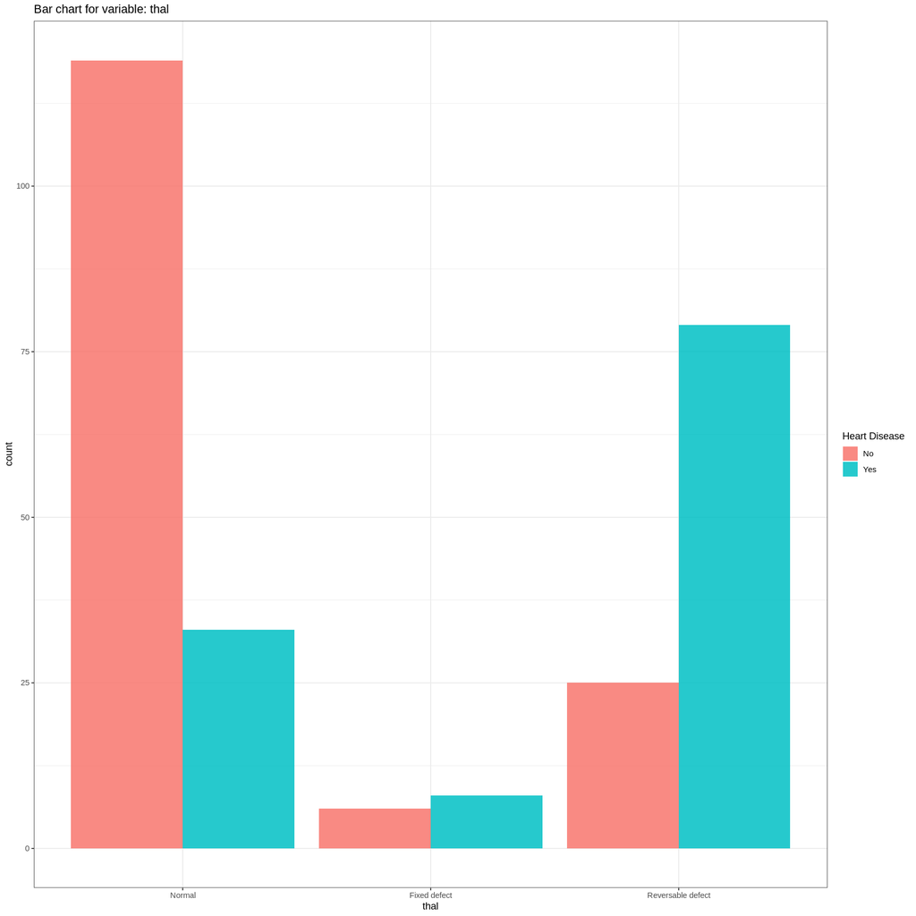

```r
# Definindo o nome da variável a ser analisada.

col <- 'thal'

# Criando um gráfico de barras para a variável especificada.

barPlot(col, data)
```

Detectamos que predominantemente a maior parte dos indivíduos saudáveis apresenta um resutlado **normal** para o teste de stress com tálio. Porém, quando o resultado é um **defeito fixo** ou um **defeito reversível** a predominância é de indivíduos com problemas cardíacos.

```r
# Calculando algumas estatísticas para a variável especificada.

stats <- varStats(col, data)

# Verificando a distribuição de registros entre as classes da variável.

stats$variableClasses
```

A tibble: 3 × 3

| thal <fct> | count <int> | prop <dbl> |
| --- | --- | --- |
| Normal | 152 | 56.296296 |
| Fixed defect | 14 | 5.185185 |
| Reversable defect | 104 | 38.518519 |

Cerca de **56.3%** dos registros dos indivíduos apresentou um resultado **normal**.

```r
# Verificando a distribuição de registros entre as classes da variável especificada agrupadas pela variável alvo.

stats$variableClassesGroupedByTargetVariable
```

A grouped_df: 6 × 4

| thal <fct> | heart_disease <fct> | count <int> | prop <dbl> |
| --- | --- | --- | --- |
| Normal | No | 119 | 44.074074 |
| Normal | Yes | 33 | 12.222222 |
| Fixed defect | No | 6 | 2.222222 |
| Fixed defect | Yes | 8 | 2.962963 |
| Reversable defect | No | 25 | 9.259259 |
| Reversable defect | Yes | 79 | 29.259259 |

#### **3.3.15 Variável heart_disease**

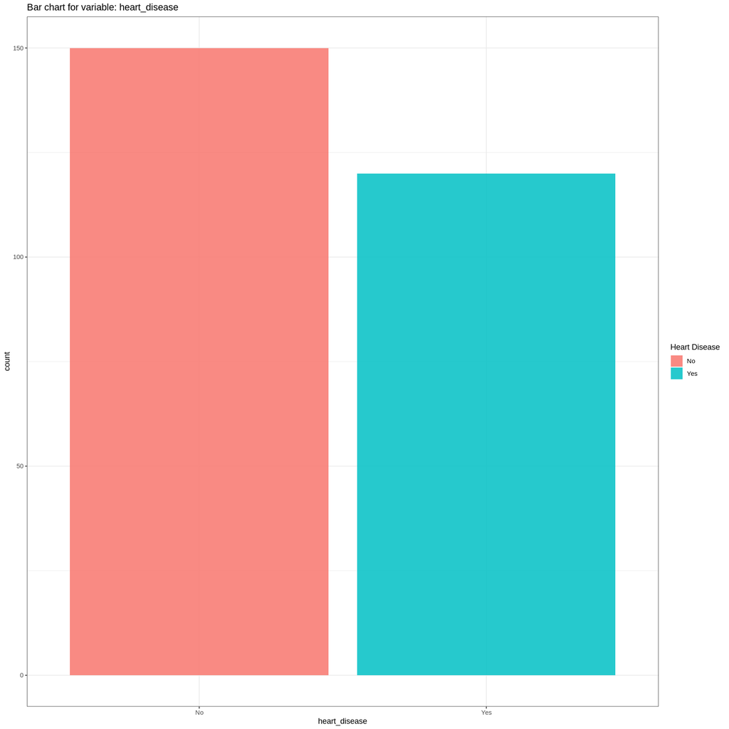

```r
# Definindo o nome da variável a ser analisada.

col <- 'heart_disease'

# Criando um gráfico de barras para a variável especificada.

barPlot(col, data)
```

Detectamos um desbalanceamento entre as classes da variável preditora.

```r
# Calculando algumas estatísticas para a variável especificada.

stats <- varStats(col, data)

# Verificando a distribuição de registros entre as classes da variável.

stats$variableClasses
```

A tibble: 2 × 3

| heart_disease <fct> | count <int> | prop <dbl> |
| --- | --- | --- |
| No | 150 | 55.55556 |
| Yes | 120 | 44.44444 |

## **4. Feature Engineering**

### **4.1 Importando bibliotecas necessárias**

Importaremos todas as bilbiotecas necessárias para a realização das etapas de modelagem preditiva.

```r
# Caso não possua uma das bibliotecas importadas abaixo, a instale com o comando a seguir:

install.packages(c(
    'xgboost',
    'MLmetrics',
    'ROSE',
    'DMwR',
    'caret',
    'randomForest',
    'C50',
    'fastAdaboost',
    'data.table',
    'neuralnet'
))
```

```r
# Importando bibliotecas.

library(xgboost)
library(MLmetrics)
library(caret)
library(randomForest)
library(C50)
library(fastAdaboost)
library(ROSE)
library(DMwR)
library(neuralnet)
library(data.table)
```

### **4.2 Preparando dados para modelagem preditiva**

Muito bem, como a maior parte dos algoritmos de *Machine Learning* trabalham melhor com variáveis númericas, iremos criar uma nova cópia do conjunto de dados sem qualquer uma das modificações que implementamos para executar a fase de exploração de dados.

```r
# Carregando dataset não modificado.

data <- dataset
```

Na fase de exploração dos dados pudemos observar que as variáveis **oldpeak**, **resting_blood_pressure** e **serum_cholestoral** possuem uma assimetria à direita muita acentuada e isso pode atrapalhar a criação dos nossos modelos.

Para contornar este problema de distorção nos dados usaremos a função de transformação **log1p (ou log(x + 1))** na variável **oldpeak** e a função de tranformação **log** nas outras duas variáveis com o objetivo de diminuir a irregularidade nos dados e tornar os padrões que apresentam mais visíveis.

Para mais informações sobre como a função **log** atua sobre dados distorcidos [consulte este link](http://onlinestatbook.com/2/transformations/log.html). Para entender melhor a função **log1p** [consulte este link](https://www.johndcook.com/blog/2010/06/07/math-library-functions-that-seem-unnecessary/).

Destacamos que o principal motivo de utilizarmos a função **log1p** é há existência de valores nulos dentro dos dados da variável **oldpeak** o que inviabiliza o uso da função **log** pois o [log(0) é um valor indefinido](https://www.rapidtables.com/math/algebra/logarithm/Logarithm_of_0.html).

```r
# Aplicando a função de transformação log1p aos valores da variável oldpeak.

data$oldpeak <- log1p(data$oldpeak)

# Aplicando a função de transformação log aos valores da variável resting_blood_pressure.

data$resting_blood_pressure <- log(data$resting_blood_pressure)

# Aplicando a função de transformação log aos valores da variável serum_cholestoral.

data$serum_cholestoral <- log(data$serum_cholestoral)
```

A próxima etapa que iremos efetuar é a de escalar os valores das variáveis preditoras entre 0 e 1.

```r
# Definindo método de pré-processamento.

params <- preProcess(data %>% select(- heart_disease), method = 'range')

# Transformando os dados.

data <- predict(params, data)

# Visualizando as primeiras linhas do dataset.

head(data)
```

A data.frame: 6 × 14

|  | age <dbl> | sex <dbl> | chest_pain_type <dbl> | resting_blood_pressure <dbl> | serum_cholestoral <dbl> | fasting_blood_sugar <dbl> | resting_electro_results <dbl> | max_heart_rate_achieved <dbl> | exercise_induced_angina <dbl> | oldpeak <dbl> | slope_of_the_peak <dbl> | number_of_major_vessels <dbl> | thal <dbl> | heart_disease <int> |
| --- | --- | --- | --- | --- | --- | --- | --- | --- | --- | --- | --- | --- | --- | --- |
| 1 | 0.8541667 | 1 | 1.0000000 | 0.4294437 | 0.6260255 | 0 | 1 | 0.2900763 | 0 | 0.61992158 | 0.5 | 1.0000000 | 0 | 2 |
| 2 | 0.7916667 | 0 | 0.6666667 | 0.2670613 | 1.0000000 | 0 | 1 | 0.6793893 | 0 | 0.48402848 | 0.5 | 0.0000000 | 1 | 1 |
| 3 | 0.5833333 | 1 | 0.3333333 | 0.3668589 | 0.4858900 | 0 | 0 | 0.5343511 | 0 | 0.13290451 | 0.0 | 0.0000000 | 1 | 2 |
| 4 | 0.7291667 | 1 | 1.0000000 | 0.4089089 | 0.4909833 | 0 | 0 | 0.2595420 | 1 | 0.09235769 | 0.5 | 0.3333333 | 1 | 1 |
| 5 | 0.9375000 | 0 | 0.3333333 | 0.3234300 | 0.5060338 | 0 | 1 | 0.3816794 | 1 | 0.09235769 | 0.0 | 0.3333333 | 0 | 1 |
| 6 | 0.7500000 | 1 | 1.0000000 | 0.3234300 | 0.2267641 | 0 | 0 | 0.5267176 | 0 | 0.17044500 | 0.0 | 0.0000000 | 1 | 1 |

Como estamos trabalhando com um problema de classificação, converteremos a variável a ser prevista para o tipo *factor*. Caso algum algoritmo solicite um ajuste específico para utilizar o conjunto de dados, faremos a modificação de forma temporária para gerar o modelo em questão e não alterar as variáveis do dataset.

```r
# Convertendo a variável a ser prevista para o tipo factor.

data$heart_disease <- as.factor(data$heart_disease)
```

## **5. Modelagem Preditiva**

### **5.1 Criando dados de treino e de teste**

Para iniciar a modelagem preditiva, devemos criar os dados de treino e de teste.

```r
# Definindo um seed.

set.seed(100)

# Criando as partições com dados de treino e de teste.

inTrain <- createDataPartition(data$heart_disease, p = .90, list = F)

# Segmentando dados de treino e de teste por partição.

train <- data[inTrain, ]
test  <- data[-inTrain, ]
```

### **5.2 Criando funções de busca dos melhores parâmetros para os modelos a serem criados**

Como não sabemos qual o algoritmo mais adequado para realizar as previsões para o nosso problema nem que valores utilizar em suas configurações, criaremos funções que gerem diferentes modelos com diferentes ajustes baseados nos seguintes algoritmos: **Random Forest**, **C 5.0**, **Adaboost**, **XGboost** e **Neuralnet**.

Adotando esta estratégia conseguiremos extrair a melhor performance de cada um dos algoritmos a serem implementados.

#### **5.2.1 Modelo Random Forest**

Note que está função também tem a capaciade de avaliar a importância de cada variável preditora a ser utilizada no modelo.

```r
# Definindo uma função para gerar diferentes modelos com diferentes valores de parametrização baseados no algoritmo
# Random Forest.

getBetterRandomForestParameters <- function(train, f, test = NULL, positive = NULL, nTree = 1:100, nNode = 1:100,
                                            importance = F, statusPrint = F) {

    # Criando o dataframe para salvar os resultados dos modelos.

    featuresRF <- data.frame()

    # Define o número total de modelos a serem criados.

    total <- length(nTree) * length(nNode)

    # Capturando o nome da variável a ser prevista.

    target <- as.character(f[[2]])

    # Define uma varíavel auxiliar para permitir o acompanhamento do progresso na avaliação dos modelos criados.

    count <- 0

    for(t in nTree) {

        for(n in nNode) {

            # Define um seed para permitir que os mesmos resultados dos experimentos sejam reproduzíveis.

            set.seed(100)

            # Cria o modelo Random Forest a ser avaliado.

            model <- randomForest(
                formula    = f,
                data       = train,
                ntree      = t,
                nodesize   = n,
                importance = importance
            )

            # Determina a Confusion Matrix para a avaliação de importância das variáveis preditoras ou para realizar
            # previsões.

            if(importance) {

                # Computa a Confusion Matrix gerada a partir do modelo criado para determinar a importância das variáveis.

                cm <- confusionMatrix(table(
                        data      = model$y,
                        reference = model$predicted
                    ),
                    positive = positive
                )

                # Armazena os parâmetros utilizados para criação do modelo e a acurácia obtida no dataframe.

                featuresRF <- rbind(featuresRF, data.frame(
                    nodes    = n,
                    nTree    = t,
                    accuracy = unname(cm$overall['Accuracy'])
                ))

            } else {

                # Realizando as previsões com o modelo baseado no algoritmo Random Forest.

                pred <- predict(model, test)

                # Criando a Confusion Matrix a partir das previsões.

                cm <- confusionMatrix(table(pred = pred, data = test[ , target]), positive = positive)

                # Armazena os parâmetros utilizados para criação do modelo, a acurácia e o score da métrica Logloss
                # obtidos no dataframe.

                featuresRF <- rbind(featuresRF, data.frame(
                    nodes    = n,
                    nTree    = t,
                    accuracy = unname(cm$overall['Accuracy']),
                    logloss  = LogLoss(predict(model, test, type = 'prob')[, positive], as.integer(test[, target]) - 1)
                ))
            }

            # Incrementa o número de modelos avaliados.

            count <- count + 1

            # Imprime a porcetagem de progresso do treinamento e a melhor acurácia ou valor da métrica logloss já alcançada.

            if(statusPrint) {

                if(importance) {
                    print(paste(100 * count / total, '%, best accuracy: ', max(featuresRF$accuracy)))
                } else {
                    print(paste(100 * count / total, '%, best LogLoss: ', min(featuresRF$logloss)))
                }
            }
        }
    }

    # Retorna o dataframe com os resultados obtidos pelo treinamento de cada modelo.

    featuresRF
}
```

#### **5.2.2 Modelo C 5.0**

```r
# Definindo uma função para gerar diferentes modelos com diferentes valores de parametrização baseados no algoritmo C 5.0.

getBetterC50Parameters <- function(train, test, cost, f, positive, trials = 1:100, statusPrint = F) {

    # Criando o dataframe para salvar os resultados dos modelos.

    featuresC50 <- data.frame()

    # Define o número total de modelos a serem criados.

    total <- length(trials)

    # Capturando o nome da variável a ser prevista.

    target <- as.character(f[[2]])

    # Define uma varíavel auxiliar para permitir o acompanhamento do progresso na avaliação dos modelos criados.

    count <- 0

    for(t in trials) {

        # Define um seed para permitir que os mesmos resultados dos experimentos sejam reproduzíveis.

        set.seed(100)

        # Criando o modelo baseado no algoritmo C 5.0.

        model_c50 <-  C5.0(
            formula = f,
            data    = train,
            trials  = t,
            rules   = T,
            cost    = cost,
            control = C5.0Control(
                winnow          = T,
                noGlobalPruning = T,
                earlyStopping   = T
            )
        )

        # Realizando as previsões com o modelo baseado no algoritmo C 5.0.

        pred <- predict(model_c50, test)

        # Criando a Confusion Matrix a partir das previsões.

        cm <- confusionMatrix(table(pred = pred, data = test[ , target]), positive = positive)

        # Armazena os parâmetros utilizados para criação do modelo, a acurácia e o score da métrica Logloss obtidos no
        #dataframe.

        featuresC50 <- rbind(featuresC50, data.frame(
            trials   = t,
            accuracy = unname(cm$overall['Accuracy']),
            logloss  = LogLoss(predict(model_c50, test, type = 'prob')[ , positive], as.integer(test[, target]) - 1)
        ))

        # Incrementa o número de modelos avaliados.

        count <- count + 1

        # Imprime a porcetagem de progresso do treinamento e o melhor valor da métrica logloss já alcançado.

        if(statusPrint) {
            print(paste(100 * count / total, '%, best LogLoss: ', min(featuresC50$logloss)))
        }
    }

    # Retorna o dataframe com os resultados obtidos pelo treinamento de cada modelo.

    featuresC50
}
```

#### **5.2.3 Modelo Adaboost**

```r
# Definindo uma função para gerar diferentes modelos com diferentes valores de parametrização baseados no algoritmo
# Adaboost.

getBetterAdaboostParameters <- function(train, test, f, positive, nIters = 1:100, treeDepth = 3, statusPrint = F) {

    # Criando o dataframe para salvar os resultados dos modelos.

    featuresAdaboost <- data.frame()

    # Define o número total de modelos a serem criados.

    total <- length(nIters) * length(treeDepth)

    # Capturando o nome da variável a ser prevista.

    target <- as.character(f[[2]])

    # Define uma varíavel auxiliar para permitir o acompanhamento do progresso na avaliação dos modelos criados.

    count <- 0

    for(n in nIters) {

        for(t in treeDepth) {

            # Define um seed para permitir que os mesmos resultados dos experimentos sejam reproduzíveis.

            set.seed(100)

            # Criando o modelo baseado no algoritmo Adaboost.

            model_adaboost <-  adaboost(
                formula    = f,
                data       = train,
                nIter      = n,
                tree_depth = t
            )

            # Realizando as previsões com o modelo baseado no algoritmo Adaboost.

            pred <- predict(model_adaboost, test, type = 'class')

            # Criando a Confusion Matrix a partir das previsões.

            cm <- confusionMatrix(table(pred = pred$class, data = test[ , target]), positive = positive)

            # Armazena os parâmetros utilizados para criação do modelo, a acurácia e o score da métrica Logloss obtidos
            # no dataframe.

            featuresAdaboost <- rbind(featuresAdaboost, data.frame(
                nIter     = n,
                treeDepth = t,
                accuracy  = unname(cm$overall['Accuracy']),
                logloss   = LogLoss(predict(model_adaboost, test, type = 'raw')$votes[, 2], as.integer(test[, target]) - 1)
            ))

            # Incrementa o número de modelos avaliados.

            count <- count + 1

            # Imprime a porcetagem de progresso do treinamento e o melhor valor da métrica logloss já alcançado.

            if(statusPrint) {
                print(paste(100 * count / total, '%, best LogLoss: ', min(featuresAdaboost$logloss)))
            }
        }
    }

    # Retorna o dataframe com os resultados obtidos pelo treinamento de cada modelo.

    featuresAdaboost
}
```

#### **5.2.4 Modelo XGboost**

```r
# Definindo uma função para gerar diferentes modelos com diferentes valores de parametrização baseados no algoritmo XGboost.

getBetterXGboostParameters <- function(train, trainTarget, test, testTarget, maxDepth = 1:10, nEta = seq(0.1, 1, 0.1),
                                       nRounds = 1:100, threshold = 0.5,  statusPrint = F) {

    # Criando o dataframe para salvar os resultados dos modelos.

    featuresXGboost <- data.frame()

    # Define o número total de modelos a serem criados.

    total <- length(maxDepth) * length(nEta) * length(nRounds)

    # Define uma varíavel auxiliar para permitir o acompanhamento do progresso na avaliação dos modelos criados.

    count <- 0

    for(m in maxDepth) {

        for(e in nEta) {

            for(r in nRounds) {

                # Define um seed para permitir que os mesmos resultados dos experimentos sejam reproduzíveis.

                set.seed(100)

                # Criando o modelo baseado no algoritmo XGboost.

                model_xgboost <- xgboost(
                    data        = train,             # Define as variáveis preditoras.
                    label       = trainTarget,       # Define a variável target.
                    max.depth   = m,                 # Define o tamanho máximo da árvore.
                    eta         = e,                 # Define a taxa de aprendizado do modelo.
                    nthread     = 16,                # Define o número de threads que devem ser usadas.
                                                     # Quanto maior for esse número, mais rápido será o treinamento.
                    nrounds     = r,                 # Define o número de iterações.
                    objective   = "binary:logistic", # Define que o modelo deve ser baseado em uma regressão
                                                     # logistica binária.
                    verbose     = F,                 # Define a exibição da queda da taxa de erro durante o treinamento.
                    eval_metric = 'logloss',         # Define a função de avaliação a ser utilizada.
                    maximize    = F                  # Define que a pontuação da avaliação deve ser minimizada.
                )

                # Realizando as previsões com o modelo baseado no algoritmo XGboost.

                pred <- predict(model_xgboost, test)

                # Definindo o threshold.

                for(th in threshold) {

                    # Classificando os resultados segundo o threshold especificado.

                    predClass <- ifelse(pred > th, 1, 0)

                    # Criando a Confusion Matrix a partir das previsões.

                    cm <- confusionMatrix(table(
                            pred = factor(predClass, levels = c(0, 1)),
                            data = factor(testTarget, levels = c(0, 1))
                        ),
                        positive =  '1'
                    )

                    # Armazena os parâmetros utilizados para criação do modelo, a acurácia e o score da métrica Logloss
                    # obtidos no dataframe.

                    featuresXGboost <- rbind(featuresXGboost, data.frame(
                        maxDepth = m,
                        th       = th,
                        eta      = e,
                        nRounds  = r,
                        accuracy = unname(cm$overall['Accuracy']),
                        logloss  = LogLoss(as.numeric(pred), testTarget)
                    ))
                }

                # Incrementa o número de modelos avaliados.

                count <- count + 1

                # Imprime a porcetagem de progresso do treinamento e a melhor acurácia já alcançada.

                if(statusPrint) {
                    print(paste(100 * count / total, '%, best LogLoss: ', min(featuresXGboost$logloss)))
                }
            }
        }
    }

    # Retorna o dataframe com os resultados obtidos pelo treinamento de cada modelo.

    featuresXGboost
}
```

#### **5.2.5 Modelo Neuralnet**

```r
# Definindo uma função para gerar diferentes modelos com diferentes valores de parametrização baseados no algoritmo
# Neuralnet.

getBetterNNParameters <- function(train, test, f, neurons = 1:100, thresholdModel = seq(0.05, 1, 0.05),
                                  thresholdClass = 0.5,  statusPrint = F) {

    # Criando o dataframe para salvar os resultados dos modelos.

    featuresNN <- data.frame()

    # Define o número total de modelos a serem criados.

    total <- length(neurons) * length(thresholdModel)

    # Capturando o nome da variável a ser prevista.

    target <- as.character(f[[2]])

    # Define uma varíavel auxiliar para permitir o acompanhamento do progresso na avaliação dos modelos criados.

    count <- 0

    for(n in neurons) {

        for(r in thresholdModel) {

                # Define um seed para permitir que os mesmos resultados dos experimentos sejam reproduzíveis.

                set.seed(100)

                # Criando o modelo baseado no algoritmo Neuralnet.

                nn <- neuralnet(
                    formula       = f,
                    data          = train,
                    hidden        = n,
                    act.fct       = "logistic",
                    stepmax       = 1e+08,
                    linear.output = FALSE,
                    threshold     = r
                )

                # Captura score da acurácia e da métrica Logloss para o modelo criado.

                metrics = tryCatch({

                    # Realiza a previsão para os dados de treino com o modelo criado.

                    pred <- predict(nn, test)

                    for(th in thresholdClass) {

                        # Classificando os resultados segundo o threshold especificado.

                        predClass <- ifelse(pred > th, 1, 0)

                        # Criando a Confusion Matrix a partir das previsões.

                        cm <- confusionMatrix(table(
                                pred = factor(predClass, levels = c(0, 1)),
                                data = factor(test[, target], levels = c(0, 1))
                            ),
                            positive =  '1'
                        )

                        # Adiciona a configuração e os resultados obtidos pelo modelo avaliado ao dataframe.

                        featuresNN <- rbind(featuresNN, data.frame(
                            n              = n,
                            thresholdModel = r,
                            thresholdClass = th,
                            Accuracy       = unname(cm$overall['Accuracy']),
                            logloss        = LogLoss(pred, test[, target])
                        ))
                    }

                }, error = function(e) {

                    # Caso a rede neural não consiga convergir, retorna o valor NA para o score da acurácia e
                    # da métrica Logloss para o modelo criado.

                    featuresNN <- rbind(featuresNN, data.frame(
                        n              = n,
                        thresholdModel = r,
                        thresholdClass = th,
                        Accuracy       = NA,
                        logloss        = NA
                    ))
                })

                # Incrementa o número de modelos avaliados.

                count <- count + 1

                # Imprime a porcetagem de progresso do treinamento e a melhor acurácia já alcançada.

                if(statusPrint) {
                    print(paste(100 * count / total, '%, best LogLoss: ', min(featuresNN$logloss)))
                }
        }
    }

    # Eliminando resultados de modelos que não convergiram.

    featuresNN <- featuresNN[!is.na(featuresNN$logloss), ]

    # Retorna o dataframe com os resultados obtidos pelo treinamento de cada modelo.

    featuresNN
}
```

### **5.3 Avaliando a importância das variáveis com o algoritmo Random Forest**

Antes de iniciarmos a criação dos modelos propriamente dita, é interessante definirmos o quanto cada variável dentro do dataset ajuda a prever o valor da variável *target*.

Para fazermos isto, utilizaremos o algoritmo **Random Forest** para computar tais valores. Como não sabemos qual o ajuste de parâmetros do algoritmo é mais adequado para o nosso conjunto de dados, criaremos modelos que possuam de 1 a 100 árvores com 1 a 100 nós.

Salvaremos a acurárica de cada modelo em um Dataframe. Note que por ser um processo de treinamento que tende a demandar muito tempo para ser processado, salvaremos os resultados obtidos em um arquivo CSV que pode ser carregado com todos os resultados gerados pelo bloco de código a seguir.

```r
# Gerando diferentes modelos baseados no algoritmo Random Forest para avaliar a importância das variáveis preditoras
# no conjunto de dados.

impFeaturesRF <- getBetterRandomForestParameters(data, f = heart_disease ~ ., importance = T, statusPrint = T)
```

```r
# Salvando dataframe com os resultados gerados em um arquivo .csv.

fwrite(impFeaturesRF, '/content/outputs/impFeaturesRF.csv')
```

Caso deseje pular a execução do bloco de código anterior, basta carregar os resultados já processados que estão salvos no arquivo CSV abaixo:

```r
# Carregando dataframe com os resultados obtidos para cada modelo Random Forest criado.

impFeaturesRF <- fread('/content/outputs/impFeaturesRF.csv')
```

Imprimiremos os registros dos modelos que apresentaram a melhor acurácia.

```r
# Imprimindo registros dos modelos que alcançaram a maior acurácia.

bestRF <- impFeaturesRF[impFeaturesRF$accuracy == max(impFeaturesRF$accuracy), ]

bestRF
```

A data.table: 5 × 3

| nodes <int> | nTree <int> | accuracy <dbl> |
| --- | --- | --- |
| 89 | 89 | 0.8592593 |
| 99 | 91 | 0.8592593 |
| 99 | 94 | 0.8592593 |
| 99 | 98 | 0.8592593 |
| 99 | 99 | 0.8592593 |

Caso mais de um modelo apresente a maior acurácia registrada dentro do dataset, selecionaremos o primeiro que foi listado para ser utilizado nas etapas seguintes.

```r
# Selecionando o primeiro registro dentro do dataframe.

bestRF <- bestRF[1,]
```

Recriaremos este modelo e imprimiremos suas estatísticas.

```r
# Define um seed para permitir que o mesmo resultado do experimento seja reproduzível.

set.seed(100)

# Criando modelo.

model <- randomForest(
    formula    = heart_disease ~ .,
    data       = data,
    ntree      = bestRF$nTree,
    nodesize   = bestRF$nodes,
    importance = T
 )

# Imprimindo o modelo.

model
```

```
Call:
 randomForest(formula = heart_disease ~ ., data = data, ntree = bestRF$nTree,      nodesize = bestRF$nodes, importance = T)
               Type of random forest: classification
                     Number of trees: 89
No. of variables tried at each split: 3

        OOB estimate of  error rate: 14.07%
Confusion matrix:
    1   2 class.error
1 127  23   0.1533333
2  15 105   0.1250000
```

Agora podemos plotar o modelo em um gráfico e verificar o nível de importância das variáveis do dataset para prever a variável alvo.

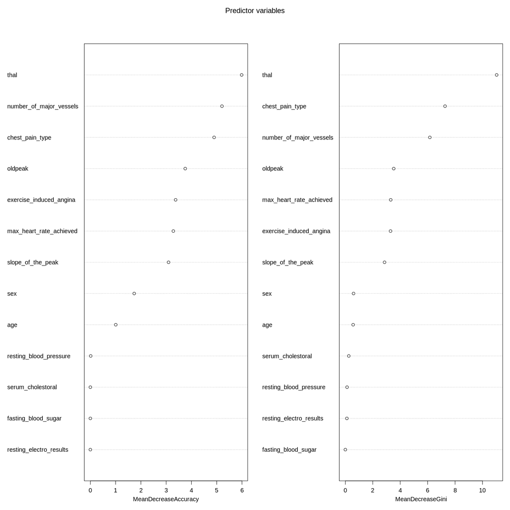

```r
# Plotando gráfico para visualizar o nível de importância de cada variável no processo de predição da variável alvo.

v <- as.data.frame(varImpPlot(model, main = 'Predictor variables'))
```

Também podemos mensurar numericamente o quanto cada variável auxilia no processo de predição da variável alvo.

```r
# Captura em ordem decrescente de nível de importância o nome das variáveis.

names <- rownames(v[order(v[, 'MeanDecreaseAccuracy'], decreasing = T),])

# Imprime o resultado.

v[order(v[, 'MeanDecreaseAccuracy'], decreasing = T), ]
```

A data.frame: 13 × 2

|  | MeanDecreaseAccuracy <dbl> | MeanDecreaseGini <dbl> |
| --- | --- | --- |
| thal | 5.98733638 | 11.0332430 |
| number_of_major_vessels | 5.20768150 | 6.1614050 |
| chest_pain_type | 4.89701493 | 7.2690872 |
| oldpeak | 3.75437555 | 3.5279328 |
| exercise_induced_angina | 3.37432499 | 3.2947821 |
| max_heart_rate_achieved | 3.28352898 | 3.3087980 |
| slope_of_the_peak | 3.09433613 | 2.8576053 |
| sex | 1.73545248 | 0.5974387 |
| age | 1.00566577 | 0.5678321 |
| resting_blood_pressure | 0.01414144 | 0.1245467 |
| serum_cholestoral | 0.00000000 | 0.2509163 |
| fasting_blood_sugar | 0.00000000 | 0.0000000 |
| resting_electro_results | 0.00000000 | 0.1117128 |

### **5.4 Feature Selection**

Bom, vamos considerar a medida **MeanDecreaseAccuracy** calculada na fase anterior. Sabemos que as variáveis mais importantes para prever a variável alvo são aquelas que apresentam os maiores valores para esta grandeza.

Sendo assim, iremos eliminar as 3 variáveis que apresentaram o menor valor de importância. Como o gráfico anterior nos mostra, o nome destas variáveis preditoras são: **serum_cholestoral**, **fasting_blood_sugar** e **resting_electro_results**.

```r
# Definindo um vetor com o nome das variáveis que devem ser desconsideras pelo modelo a ser treinado.

d <- c('fasting_blood_sugar', 'serum_cholestoral', 'resting_electro_results', 'heart_disease')

# Definindo fórmula a ser utilizada pelo modelo a ser treinado.

f <- heart_disease ~ . - fasting_blood_sugar - serum_cholestoral - resting_electro_results
```

### **5.5 Criando modelos**

#### **5.5.1 Modelo Random Forest**

```r
# Gerando diferentes modelos baseados no algoritmo Random Forest e determinando sua acurácia e score para a métrica LogLoss.

featuresRF <- getBetterRandomForestParameters(
    train       = train,
    test        = test,
    f           = f,
    positive    = '2',
    statusPrint = T, nTree = 1:200, nNode = 1:200
)
```

```r
# Salvando dataframe com os resultados gerados em um arquivo .csv.

fwrite(featuresRF, '/content/outputs/featuresRF.csv')
```

Caso deseje pular a execução do bloco de código anterior, basta carregar os resultados já processados que estão salvos no arquivo CSV abaixo:

```r
# Carregando dataframe com os resultados obtidos para cada modelo Random Forest criado.

featuresRF <- fread('/content/outputs/featuresRF.csv')
```

Imprimiremos os registros dos modelos que apresentaram o menor score para a métrica *Logloss*.

```r
# Imprimindo registros dos modelos que alcançaram o menor score para a métrica Logloss.

bestRF <- featuresRF[featuresRF$logloss == min(featuresRF$logloss), ]

bestRF
```

A data.table: 1 × 4

| nodes <int> | nTree <int> | accuracy <dbl> | logloss <dbl> |
| --- | --- | --- | --- |
| 28 | 5 | 0.962963 | 0.2005249 |

Caso mais de um modelo apresente o menor score para a métrica *Logloss* registrado dentro do dataset, selecionaremos o primeiro que foi listado para ser utilizado nas etapas seguintes.

```r
# Selecionando o primeiro registro dentro do dataframe.

bestRF <- bestRF[1,]
```

Recriaremos este modelo e imprimiremos suas estatísticas.

```r
# Define um seed para permitir que o mesmo resultado do experimento seja reproduzível.

set.seed(100)

# Criando modelo.

model_rf <- randomForest(
    formula  = f,
    data     = train,
    ntree    = bestRF$nTree,
    nodesize = bestRF$nodes
)

# Imprimindo o modelo.

model_rf
```

```
Call:
 randomForest(formula = f, data = train, ntree = bestRF$nTree,      nodesize = bestRF$nodes)
               Type of random forest: classification
                     Number of trees: 5
No. of variables tried at each split: 3

        OOB estimate of  error rate: 23.15%
Confusion matrix:
    1  2 class.error
1 108 12   0.1000000
2  38 58   0.3958333
```

```r
# Realizando as previsões com o modelo baseado no algoritmo Random Forest.

pred <- predict(model_rf, test)
```

```r
# Criando a Confusion Matrix a partir das previsões.

cm <- confusionMatrix(table(pred = pred, data = test$heart_disease), positive = '2')

# Visualizando a Confusion Matrix.

cm
```

```
Confusion Matrix and Statistics

    data
pred  1  2
   1 15  1
   2  0 11

               Accuracy : 0.963
                 95% CI : (0.8103, 0.9991)
    No Information Rate : 0.5556
    P-Value [Acc > NIR] : 2.896e-06

                  Kappa : 0.9244

 Mcnemar's Test P-Value : 1

            Sensitivity : 0.9167
            Specificity : 1.0000
         Pos Pred Value : 1.0000
         Neg Pred Value : 0.9375
             Prevalence : 0.4444
         Detection Rate : 0.4074
   Detection Prevalence : 0.4074
      Balanced Accuracy : 0.9583

       'Positive' Class : 2
```

Perfeito, nosso primeiro modelo foi criado! Vamos salvar os scores de sua *acurácia* e de sua métrica *Logloss* em um dataframe.

```r
# Salvando scores das métricas analisadas em um dataframe.

scoreModels <- data.frame(
    accuracy  = unname(cm$overall['Accuracy']),
    logloss   = LogLoss(predict(model_rf, test, type = 'prob')[, '2'], as.integer(test$heart_disease) - 1),
    row.names = 'randomForest'
)
```

#### **5.5.2 Modelo C 5.0**

```r
# Definindo a matriz de custos a ser utilizada pelo modelo.

cost <- matrix(c(0, 1, 0.1, 0), nrow = 2, dimnames = list(c("No", "Yes"), c("No", "Yes")))

# Visualizando a matriz.

cost
```

A matrix: 2 × 2 of type dbl

|  | No | Yes |
| --- | --- | --- |
| No | 0 | 0.1 |
| Yes | 1 | 0.0 |

```r
# Gerando diferentes modelos baseados no algoritmo C 5.0 e determinando sua acurácia e score para a métrica LogLoss.

featuresC50 <- getBetterC50Parameters(
    train       = train,
    test        = test,
    cost        = cost,
    f           = f,
    positive    = '2',
    statusPrint = T
)
```

```r
# Salvando dataframe com os resultados gerados em um arquivo .csv.

fwrite(featuresC50, '/content/outputs/featuresC50.csv')
```

Caso deseje pular a execução do bloco de código anterior, basta carregar os resultados já processados que estão salvos no arquivo CSV abaixo:

```r
# Carregando dataframe com os resultados obtidos para cada modelo C 5.0 criado.

featuresC50 <- fread('/content/outputs/featuresC50.csv')
```

Imprimiremos os registros dos modelos que apresentaram o menor score para a métrica *Logloss*.

```r
# Imprimindo registros dos modelos que alcançaram o menor score para a métrica Logloss.

bestC50 <- featuresC50[featuresC50$logloss == min(featuresC50$logloss), ]

bestC50
```

A data.table: 1 × 3

| trials <int> | accuracy <dbl> | logloss <dbl> |
| --- | --- | --- |
| 4 | 0.8518519 | 0.2511706 |

Caso mais de um modelo apresente o menor score para a métrica *Logloss* registrado dentro do dataset, selecionaremos o primeiro que foi listado para ser utilizado nas etapas seguintes.

```r
# Selecionando o primeiro registro dentro do dataframe.

bestC50 <- bestC50[1,]
```

Recriaremos este modelo e imprimiremos suas estatísticas.

```r
# Define um seed para permitir que os mesmos resultados dos experimentos sejam reproduzíveis.

set.seed(100)

# Criando o modelo baseado no algoritmo C 5.0.

model_c50 <-  C5.0(
    form   = f,
    data   = train,
    trials = bestC50$trials,
    rules  = T,
    cost   = cost,
    control = C5.0Control(
        winnow          = T,
        noGlobalPruning = T,
        earlyStopping   = T
    )
)
```

```r
# Realizando as previsões com o modelo baseado no algoritmo C 5.0.

pred <- predict(model_c50, test)
```

```r
# Criando a Confusion Matrix a partir das previsões.

cm <- confusionMatrix(table(pred = pred, data = test$heart_disease), positive = '2')

# Visualizando a Confusion Matrix.

cm
```

```
Confusion Matrix and Statistics

    data
pred  1  2
   1 15  4
   2  0  8

               Accuracy : 0.8519
                 95% CI : (0.6627, 0.9581)
    No Information Rate : 0.5556
    P-Value [Acc > NIR] : 0.001145

                  Kappa : 0.6897

 Mcnemar's Test P-Value : 0.133614

            Sensitivity : 0.6667
            Specificity : 1.0000
         Pos Pred Value : 1.0000
         Neg Pred Value : 0.7895
             Prevalence : 0.4444
         Detection Rate : 0.2963
   Detection Prevalence : 0.2963
      Balanced Accuracy : 0.8333

       'Positive' Class : 2
```

```r
# Salvando scores das métricas analisadas em um dataframe.

scoreModels <- rbind(scoreModels, data.frame(
    accuracy  = unname(cm$overall['Accuracy']),
    logloss   = LogLoss(predict(model_c50, test, type = 'prob')[ , '2'], as.integer(test$heart_disease) - 1),
    row.names = 'C5.0'
))
```

#### **5.5.3 Modelo Adaboost**

```r
# Define um seed para permitir que os mesmos resultados dos experimentos sejam reproduzíveis.

set.seed(100)

# Gerando diferentes modelos baseados no algoritmo Adaboost e determinando sua acurácia e score para a métrica LogLoss.

featuresAdaboost <- getBetterAdaboostParameters(
    train       = train,
    test        = test,
    f           = f,
    positive    = '2',
    statusPrint = T
)
```

```r
# Salvando dataframe com os resultados gerados em um arquivo .csv.

fwrite(featuresAdaboost, '/content/outputs/featuresAdaboost.csv')
```

Caso deseje pular a execução do bloco de código anterior, basta carregar os resultados já processados que estão salvos no arquivo CSV abaixo:

```r
# Carregando dataframe com os resultados obtidos para cada modelo Adaboost criado.

featuresAdaboost <- fread('/content/outputs/featuresAdaboost.csv')
```

Imprimiremos os registros dos modelos que apresentaram o menor score para a métrica *Logloss*.

```r
# Imprimindo registros dos modelos que alcançaram o menor score para a métrica Logloss.

bestAdaboost <- featuresAdaboost[featuresAdaboost$logloss == min(featuresAdaboost$logloss), ]

bestAdaboost
```

A data.table: 1 × 4

| nIter <int> | treeDepth <int> | accuracy <dbl> | logloss <dbl> |
| --- | --- | --- | --- |
| 1 | 3 | 0.7037037 | 4.266795 |

Caso mais de um modelo apresente o menor score para a métrica *Logloss* registrado dentro do dataset, selecionaremos o primeiro que foi listado para ser utilizado nas etapas seguintes.

```r
# Selecionando o primeiro registro dentro do dataframe.

bestAdaboost <- bestAdaboost[1,]
```

Recriaremos este modelo e imprimiremos suas estatísticas.

```r
# Define um seed para permitir que os mesmos resultados dos experimentos sejam reproduzíveis.

set.seed(100)

# Criando o modelo baseado no algoritmo Adaboost.

model_adaboost <-  adaboost(
    formula = f,
    data    = train,
    nIter   = bestAdaboost$nIter
)
```

```r
# Realizando as previsões com o modelo baseado no algoritmo Adaboost.

pred <- predict(model_adaboost, test, type = 'class')
```

```r
# Criando a Confusion Matrix a partir das previsões.

cm <- confusionMatrix(table(pred = pred$class, data = test$heart_disease), positive = '2')

# Visualizando a Confusion Matrix.

cm
```

```
Confusion Matrix and Statistics

    data
pred  1  2
   1 10  3
   2  5  9

               Accuracy : 0.7037
                 95% CI : (0.4982, 0.8625)
    No Information Rate : 0.5556
    P-Value [Acc > NIR] : 0.08606

                  Kappa : 0.4098

 Mcnemar's Test P-Value : 0.72367

            Sensitivity : 0.7500
            Specificity : 0.6667
         Pos Pred Value : 0.6429
         Neg Pred Value : 0.7692
             Prevalence : 0.4444
         Detection Rate : 0.3333
   Detection Prevalence : 0.5185
      Balanced Accuracy : 0.7083

       'Positive' Class : 2
```

```r
# Salvando scores das métricas analisadas em um dataframe.

scoreModels <- rbind(scoreModels, data.frame(
    accuracy  = unname(cm$overall['Accuracy']),
    logloss   = LogLoss(predict(model_adaboost, test, type = 'raw')$votes[, 2], as.integer(test$heart_disease) - 1),
    row.names = 'adaboost'
))
```

#### **5.5.4 Modelo XGboost**

```r
# Gerando diferentes modelos baseados no algoritmo Adaboost e determinando sua acurácia e score para a métrica LogLoss.

featuresXGboost <- getBetterXGboostParameters(
    train       = as.matrix(train %>% select(-d)),
    trainTarget = as.integer(train$heart_disease) - 1,
    test        = as.matrix(test %>% select(-d)),
    testTarget  = as.integer(test$heart_disease) - 1,
    statusPrint = T
)
```

```r
# Salvando dataframe com os resultados gerados em um arquivo .csv.

fwrite(featuresXGboost, '/content/outputs/featuresXGboost.csv')
```

Caso deseje pular a execução do bloco de código anterior, basta carregar os resultados já processados que estão salvos no arquivo CSV abaixo:

```r
# Carregando dataframe com os resultados obtidos para cada modelo XGboost criado.

featuresXGboost <- fread('/content/outputs/featuresXGboost.csv')
```

Imprimiremos os registros dos modelos que apresentaram o menor score para a métrica *Logloss*.

```r
# Imprimindo registros dos modelos que alcançaram o menor score para a métrica Logloss.

bestXGboost <- featuresXGboost[featuresXGboost$logloss == min(featuresXGboost$logloss), ]

bestXGboost
```

A data.table: 1 × 6

| maxDepth <int> | th <dbl> | eta <dbl> | nRounds <int> | accuracy <dbl> | logloss <dbl> |
| --- | --- | --- | --- | --- | --- |
| 1 | 0.5 | 1 | 31 | 0.8518519 | 0.3528369 |

Caso mais de um modelo apresente o menor score para a métrica *Logloss* registrado dentro do dataset, selecionaremos o primeiro que foi listado para ser utilizado nas etapas seguintes.

```r
# Selecionando o primeiro registro dentro do dataframe.

bestXGboost <- bestXGboost[1,]
```

Recriaremos este modelo e imprimiremos suas estatísticas.

```r
# Define um seed para permitir que os mesmos resultados dos experimentos sejam reproduzíveis.

set.seed(100)

# Criando o modelo baseado no algoritmo XGboost.

  model_xgboost <- xgboost(
      data        = as.matrix(train %>% select(-d )) ,   # Define as variáveis preditoras.
      label       = as.integer(train$heart_disease) - 1, # Define a variável target.
      max.depth   = bestXGboost$maxDepth, # Define o tamanho máximo da árvore.
      eta         = bestXGboost$eta,      # Define a taxa de aprendizado do modelo.
      nthread     = 16,                   # Define o número de threads que devem ser usadas.
                                          # Quanto maior for esse número, mais rápido será o treinamento.
      nrounds     = bestXGboost$nRounds,  # Define o número de iterações.
      objective   = "binary:logistic",    # Define que o modelo deve ser baseado em uma regressão logistica binária.
      verbose     = T,                    # Define a exibição da queda da taxa de erro durante o treinamento.
      eval_metric = 'logloss',            # Define a função de avaliação a ser utilizada.
      maximize    = F                     # Define que a pontuação da avaliação deve ser minimizada.
)
```

```r
# Realizando as previsões com o modelo baseado no algoritmo XGboost.

pred <- predict(model_xgboost, as.matrix(test %>% select(-d)))
```

```r
# Definindo o threshold.

th <- bestXGboost$th

# Classificando os resultados segundo o threshold especificado.

predClass <- ifelse(pred > th, 1, 0)
```

```r
# Criando a Confusion Matrix a partir das previsões.

cm <- confusionMatrix(table(pred = predClass, data = as.integer(test$heart_disease) - 1), positive = '1')

# Visualizando a Confusion Matrix.

cm
```

```
Confusion Matrix and Statistics

    data
pred  0  1
   0 12  1
   1  3 11

               Accuracy : 0.8519
                 95% CI : (0.6627, 0.9581)
    No Information Rate : 0.5556
    P-Value [Acc > NIR] : 0.001145

                  Kappa : 0.7049

 Mcnemar's Test P-Value : 0.617075

            Sensitivity : 0.9167
            Specificity : 0.8000
         Pos Pred Value : 0.7857
         Neg Pred Value : 0.9231
             Prevalence : 0.4444
         Detection Rate : 0.4074
   Detection Prevalence : 0.5185
      Balanced Accuracy : 0.8583

       'Positive' Class : 1
```

```r
# Salvando scores das métricas analisadas em um dataframe.

scoreModels <- rbind(scoreModels, data.frame(
    accuracy  = unname(cm$overall['Accuracy']),
    logloss   = LogLoss(as.numeric(pred), as.matrix(as.integer(test$heart_disease) - 1)),
    row.names = 'XGboost'
))
```

#### **5.5.5 Modelo Neuralnet**

```r
# Gerando diferentes modelos baseados no algoritmo Neuralnet e determinando sua acurácia e score para a métrica LogLoss.

featuresNN <- getBetterNNParameters(
    train       = train %>% mutate(heart_disease = as.integer(train$heart_disease) - 1),
    test        = test %>% mutate(heart_disease = as.integer(test$heart_disease) - 1),
    f           = f,
    statusPrint = T
)
```

```r
# Salvando dataframe com os resultados gerados em um arquivo .csv.

fwrite(featuresNN, '/content/outputs/featuresNN.csv')
```

Caso deseje pular a execução do bloco de código anterior, basta carregar os resultados já processados que estão salvos no arquivo CSV abaixo:

```r
# Carregando dataframe com os resultados obtidos para cada modelo Neuralnet criado.

featuresNN <- fread('/content/outputs/featuresNN.csv')
```

Imprimiremos os registros dos modelos que apresentaram o menor score para a métrica *Logloss*.

```r
# Imprimindo registros dos modelos que alcançaram o menor score para a métrica Logloss.

bestNN <- featuresNN[featuresNN$logloss == min(featuresNN$logloss), ]

bestNN
```

A data.table: 16 × 5

[output not shown]

Caso mais de um modelo apresente o menor score para a métrica *Logloss* registrado dentro do dataset, selecionaremos o primeiro que foi listado para ser utilizado nas etapas seguintes.

```r
# Selecionando o primeiro registro dentro do dataframe.

bestNN <- bestNN[1,]
```

Recriaremos este modelo e imprimiremos suas estatísticas.

```r
# Define um seed para permitir que os mesmos resultados dos experimentos sejam reproduzíveis.

set.seed(100)

# Criando o modelo baseado no algoritmo Neuralnet

nn <- neuralnet(
    formula       = f,
    data          = train %>% mutate(heart_disease = as.integer(train$heart_disease) - 1),
    hidden        = bestNN$n,
    act.fct       = "logistic",
    stepmax       = 1e+08,
    linear.output = FALSE,
    threshold     = bestNN$thresholdModel
)
```

```r
# Realizando as previsões com o modelo baseado no algoritmo Neuralnet.

pred <- predict(nn, test %>% mutate(heart_disease = as.integer(test$heart_disease) - 1))
```

```r
# Definindo o threshold.

th <- bestNN$thresholdClass

# Classificando os resultados segundo o threshold especificado.

predClass <- ifelse(pred > th, 1, 0)
```

```r
# Criando a Confusion Matrix a partir das previsões.

cm <- confusionMatrix(table(
        pred = predClass,
        data = as.integer(test$heart_disease) - 1
    ),
    positive = '1'
)

# Visualizando a Confusion Matrix.

cm
```

```
Confusion Matrix and Statistics

    data
pred  0  1
   0 12  3
   1  3  9

               Accuracy : 0.7778
                 95% CI : (0.5774, 0.9138)
    No Information Rate : 0.5556
    P-Value [Acc > NIR] : 0.01448

                  Kappa : 0.55

 Mcnemar's Test P-Value : 1.00000

            Sensitivity : 0.7500
            Specificity : 0.8000
         Pos Pred Value : 0.7500
         Neg Pred Value : 0.8000
             Prevalence : 0.4444
         Detection Rate : 0.3333
   Detection Prevalence : 0.4444
      Balanced Accuracy : 0.7750

       'Positive' Class : 1
```

```r
# Salvando scores das métricas analisadas em um dataframe.

scoreModels <- rbind(scoreModels, data.frame(
    accuracy  = unname(cm$overall['Accuracy']),
    logloss   = LogLoss(pred, as.integer(test$heart_disease) - 1),
    row.names = 'Neuralnet'
))
```

### **5.6 Determinando o melhor modelo**

Determinaremos qual modelo teve o melhor desempenho para o conjunto de dados de teste a partir do score da métrica **LogLoss**.

A métrica **LogLoss** quantifica a precisão de um classificador penalizando classificações falsas. Quando minimizamos seu score estamos basicamente maximizando a **precisão** do modelo. Ou seja, o modelo que apresentar o menor valor para esta métrica será aquele que irá classificar corretamente a maior proporção de pacientes que efetivamente apresentam alguma doença cardíaca.

É interessante refletir sobre isso, pois não queremos classificar indivíduos saudáveis como doentes e submetê-los a tramentos desnecessários, caros ou até mesmo prejudiciais a saúde de pessoas sãs.

```r
# Exibindo dataframe com as métricas de performance dos melhores modelos treinados com cada algoritmo implementado.

scoreModels
```

A data.frame: 5 × 2

|  | accuracy <dbl> | logloss <dbl> |
| --- | --- | --- |
| randomForest | 0.9629630 | 0.2005249 |
| C5.0 | 0.8518519 | 0.2511706 |
| adaboost | 0.7037037 | 4.2667947 |
| XGboost | 0.8518519 | 0.3528369 |
| Neuralnet | 0.7777778 | 0.4308035 |

```r
# Determinando o modelo que teve o melhor score para a métrica LogLoss.

scoreModels[scoreModels$logloss == min(scoreModels$logloss), ]
```

A data.frame: 1 × 2

|  | accuracy <dbl> | logloss <dbl> |
| --- | --- | --- |
| randomForest | 0.962963 | 0.2005249 |

Por fim, concluímos que o algoritmo que obteve a melhor performance para os critérios que adotamos foi o **Random Forest**.

# **Entre em contato comigo!**

Caso tenha alguma dúvida, sugestão ou apenas queira trocar uma ideia sobre este projeto, não hesite em entrar em contato comigo!

|  | E-mail |  | [Linkedin](https://www.linkedin.com/in/franklinfs390/) |  | [Github](https://github.com/franklin390) |  | Site |
| --- | --- | --- | --- | --- | --- | --- | --- |